# Model Deployment : Machine Learning Model Experiment Logging and Tracking Using Open-Source Frameworks

### [**John Pauline Pineda**](https://github.com/JohnPaulinePineda) *August 10, 2025*

- **1. Table of Contents**
  - 1.1 Data Background
  - 1.2 Data Description
  - 1.3 Data Quality Assessment
  - 1.4 Data Preprocessing
    - 1.4.1 Data Splitting
    - 1.4.2 Data Profiling
    - 1.4.3 Category Aggregation and Encoding
    - 1.4.4 Outlier and Distributional Shape Analysis
    - 1.4.5 Collinearity
  - 1.5 Data Exploration
    - 1.5.1 Exploratory Data Analysis
    - 1.5.2 Hypothesis Testing
  - 1.6 Premodelling Data Preparation
    - 1.6.1 Preprocessed Data Description
    - 1.6.2 Preprocessing Pipeline Development
  - 1.7 Ensemble Model Development, Logging and Tracking using the MLflow Framework
    - 1.7.1 Random Forest
    - 1.7.2 AdaBoost
    - 1.7.3 Gradient Boosting
    - 1.7.4 XGBoost
    - 1.7.5 Light GBM
    - 1.7.6 CatBoost
    - 1.7.7 Experiment Organization
    - 1.7.8 Run Comparison
    - 1.7.9 Artifact Storage
    - 1.7.10 Model Registry
    - 1.7.11 Model Inference
    - 1.7.12 Model Deployment
  - 1.8 Consolidated Findings
- **2. Summary**
- **3. References**

# 1. Table of Contents

This project explores **open-source solutions for managing the end-to-end lifecycle of machine learning models**, focusing on the use of **MLflow** for experiment tracking, model selection, and production deployment in **Python**. The objective was to design a reproducible workflow for evaluating multiple ensemble classifiers, selecting the optimal candidate based on validation and cross-validation metrics, and operationalizing the chosen model for production use. The project workflow involved several stages: first, hyperparameter tuning experiments were conducted across multiple ensemble model types, with all runs logged and organized in the **MLflow Tracking UI**. Next, optimal candidates were identified for each model family by programmatically querying run metrics, and the best overall model was selected based on a multi-metric ranking strategy. This model was then registered in the **MLflow Model Registry**, ensuring version-controlled storage alongside associated artifacts and metadata. To enable stable and maintainable production usage, the registered model was assigned a symbolic alias allowing seamless loading of the production model without hardcoding version numbers and simplifying future updates. The selected model was then evaluated on an independent test set to confirm generalization performance before being loaded for production inference via the **MLflow PyFunc** interface. The entire process—from experiment tracking to production deployment—was automated through the **MLflow Python API**, demonstrating how open-source MLOps tooling can streamline model governance, reproducibility, and deployment. All results were consolidated in a **Summary** presented at the end of the document.

[Machine Learning Model Lifecycle Management](https://mlflow.org/) is the systematic process of overseeing a model’s journey from initial development through production deployment, monitoring, and eventual retirement. In the context of MLOps, it encompasses every stage of a model’s evolution — including data preparation, model training, evaluation, version control, deployment, monitoring, retraining, and governance. The goal is to ensure that models remain accurate, reliable, and aligned with evolving business needs over time. Effective lifecycle management addresses challenges such as model drift, reproducibility, compliance, and scalability, while integrating automation to reduce operational overhead. It promotes collaboration between data scientists, engineers, and operations teams by using standardized processes and tooling to ensure smooth transitions between research and production environments. In modern MLOps practices, lifecycle management is supported by platforms and frameworks that provide tracking, registry, deployment orchestration, and monitoring capabilities, enabling continuous delivery and improvement of AI solutions.

[MLflow](https://mlflow.org/) is an open-source platform designed to manage the complete lifecycle of machine learning models, making it a central component in MLOps workflows. It provides four key capabilities: tracking experiments to log parameters, metrics, and artifacts; projects to package and share reproducible ML code; model registry to store, version, and annotate models; and model serving to deploy them in production environments. By offering a unified interface for logging and retrieving experiment data, MLflow helps teams compare results, trace model evolution, and enforce reproducibility. Its Model Registry acts as a centralized hub for managing versions, promoting models to production, and assigning aliases for easy referencing. MLflow supports multiple model formats — including Python functions, scikit-learn models, and deep learning frameworks — and integrates with popular deployment targets. In machine learning lifecycle management, MLflow bridges the gap between experimentation and production, providing transparency, governance, and automation across all stages.

[Run Comparison](https://mlflow.org/) in machine learning model lifecycle management refers to the process of evaluating and contrasting multiple training runs to identify the best-performing model for deployment. This involves analyzing key performance metrics, hyperparameters, and resource usage across different experiments. In MLOps, run comparison ensures that selection decisions are data-driven, reproducible, and aligned with business objectives. Within MLflow, run comparison is facilitated by both the Tracking UI and the Search API. The UI provides sortable tables and visualizations for side-by-side metric analysis, while the Search API allows programmatic filtering and ranking of runs using multiple criteria. This enables teams to systematically evaluate candidate models, pinpoint optimal configurations, and maintain an auditable record of decision-making. By combining interactive visual review with automated selection pipelines, MLflow’s run comparison capabilities streamline the transition from experimentation to registry.

[Artifact Storage](https://mlflow.org/) refers to the practice of preserving all files and outputs generated during the machine learning process, ensuring reproducibility and traceability. Artifacts can include trained model binaries, datasets, configuration files, visualizations, and evaluation reports. In the context of MLOps, centralized artifact storage ensures that every stage of model development is documented and recoverable, enabling consistent retraining, auditing, and compliance verification. In MLflow, artifact storage is integrated into the tracking system: every logged run can store artifacts either locally or on remote storage backends such as Amazon S3, Azure Blob Storage, or Google Cloud Storage. MLflow automatically organizes artifacts by experiment and run ID, allowing quick retrieval for analysis, deployment, or comparison. This eliminates the risk of “lost” models or mismatched dependencies, making artifact storage a foundational pillar of reliable lifecycle management.

[Model Registry](https://mlflow.org/) in machine learning lifecycle management serves as a centralized repository for storing, versioning, and managing machine learning models throughout their lifespan. It enables teams to track which models are in development, testing, or production, ensuring controlled and auditable promotion between stages. In MLOps, a model registry supports governance by maintaining metadata such as version numbers, creation dates, and performance metrics. MLflow’s Model Registry extends this concept by allowing users to register models directly from experiment runs, associate them with descriptions and tags, and manage aliases for flexible referencing. Instead of relying solely on numeric versions or deprecated stage labels, aliases like prod or staging allow CI/CD pipelines to dynamically pull the correct model without manual intervention. This makes the MLflow Model Registry a cornerstone for production-grade MLOps, ensuring both stability and agility in model deployment workflows.

[Model Inference](https://mlflow.org/) is the process of using a trained machine learning model to generate predictions on new, unseen data. In the context of lifecycle management, inference bridges the gap between model development and real-world application, enabling AI systems to deliver value in production environments. Inference workflows must account for input data preprocessing, model loading, execution efficiency, and output formatting. In MLflow, model inference is supported through its PyFunc interface, which provides a standardized API for loading and executing models regardless of their underlying framework. Models can be loaded by URI from local files, remote storage, or directly from the MLflow Model Registry using version numbers or aliases. This abstraction simplifies integration into applications and services, ensuring consistent and scalable predictions across environments. By standardizing inference, MLflow reduces friction in deployment and makes model serving more maintainable.

[Model Deployment](https://mlflow.org/), in the context of lifecycle management, is the process of making a trained machine learning model available in a production environment where it can serve predictions to end-users or downstream systems. Deployment strategies vary, from batch processing pipelines to real-time APIs, and must consider scalability, latency, monitoring, and security. In MLOps, deployment is not a one-time event — it is part of a continuous delivery process that supports model updates, rollback capabilities, and ongoing performance monitoring. MLflow facilitates deployment through its support for multiple serving options: models can be served locally for testing, deployed as REST APIs using MLflow’s built-in serving tools, or integrated with platforms like Kubernetes, AWS SageMaker, or Azure ML. By coupling deployment with the Model Registry and aliases, MLflow enables automated CI/CD pipelines to update production models without manual configuration changes. This approach ensures rapid, reliable, and traceable promotion of models from experimentation to production use.

## 1.1. Data Background

An open [Thyroid Disease Dataset](https://www.kaggle.com/datasets/jainaru/thyroid-disease-data/data) from [Kaggle](https://www.kaggle.com/) (with all credits attributed to [Jai Naru](https://www.kaggle.com/jainaru) and [Abuchi Onwuegbusi](https://www.kaggle.com/datasets/abuchionwuegbusi/thyroid-cancer-recurrence-prediction/data)) was used for the analysis as consolidated from the following primary sources:

1. Reference Repository entitled **Differentiated Thyroid Cancer Recurrence** from [UC Irvine Machine Learning Repository](https://archive.ics.uci.edu/dataset/915/differentiated+thyroid+cancer+recurrence)
2. Research Paper entitled **Machine Learning for Risk Stratification of Thyroid Cancer Patients: a 15-year Cohort Study** from the [European Archives of Oto-Rhino-Laryngology](https://link.springer.com/article/10.1007/s00405-023-08299-w)

This study hypothesized that the various clinicopathological characteristics influence differentiated thyroid cancer recurrence between patients.

The dichotomous categorical variable for the study is:

- Recurred - Status of the patient (Yes, Recurrence of differentiated thyroid cancer | No, No recurrence of differentiated thyroid cancer)

The predictor variables for the study are:

- Age - Patient's age (Years)
- Gender - Patient's sex (M | F)
- Smoking - Indication of smoking (Yes | No)
- Hx Smoking - Indication of smoking history (Yes | No)
- Hx Radiotherapy - Indication of radiotherapy history for any condition (Yes | No)
- Thyroid Function - Status of thyroid function (Clinical Hyperthyroidism, Hypothyroidism | Subclinical Hyperthyroidism, Hypothyroidism | Euthyroid)
- Physical Examination - Findings from physical examination including palpation of the thyroid gland and surrounding structures (Normal | Diffuse Goiter | Multinodular Goiter | Single Nodular Goiter Left, Right)
- Adenopathy - Indication of enlarged lymph nodes in the neck region (No | Right | Extensive | Left | Bilateral | Posterior)
- Pathology - Specific thyroid cancer type as determined by pathology examination of biopsy samples (Follicular | Hurthel Cell | Micropapillary | Papillary)
- Focality - Indication if the cancer is limited to one location or present in multiple locations (Uni-Focal | Multi-Focal)
- Risk - Risk category of the cancer based on various factors, such as tumor size, extent of spread, and histological type (Low | Intermediate | High)
- T - Tumor classification based on its size and extent of invasion into nearby structures (T1a | T1b | T2 | T3a | T3b | T4a | T4b)
- N - Nodal classification indicating the involvement of lymph nodes (N0 | N1a | N1b)
- M - Metastasis classification indicating the presence or absence of distant metastases (M0 | M1)
- Stage - Overall stage of the cancer, typically determined by combining T, N, and M classifications (I | II | III | IVa | IVb)
- Response - Cancer's response to treatment (Biochemical Incomplete | Indeterminate | Excellent | Structural Incomplete)

## 1.2. Data Description

```python
##################################
# Loading Python Libraries
##################################
import numpy as np
import pandas as pd
import seaborn as sns
import matplotlib.pyplot as plt
import os
import re
import pickle
%matplotlib inline

import mlflow
from mlflow.tracking import MlflowClient
from mlflow.models.signature import infer_signature
from mlflow.exceptions import RestException

import hashlib
import json
from urllib.parse import urlparse
import logging

from operator import truediv
from sklearn.preprocessing import OrdinalEncoder
from scipy import stats
from scipy.stats import pointbiserialr, chi2_contingency

from sklearn.pipeline import Pipeline
from sklearn.compose import ColumnTransformer
from sklearn.tree import DecisionTreeClassifier
from sklearn.ensemble import RandomForestClassifier, AdaBoostClassifier, GradientBoostingClassifier
from xgboost import XGBClassifier
from lightgbm import LGBMClassifier
from catboost import CatBoostClassifier
from sklearn.metrics import accuracy_score, precision_score, recall_score, f1_score, roc_auc_score, confusion_matrix, classification_report
from sklearn.model_selection import train_test_split, ParameterGrid, StratifiedShuffleSplit
from sklearn.base import clone
```

```python
##################################
# Defining file paths
##################################
DATASETS_ORIGINAL_PATH = r"datasets\original"
DATASETS_FINAL_PATH = r"datasets\final\complete"
DATASETS_FINAL_TRAIN_PATH = r"datasets\final\train"
DATASETS_FINAL_TRAIN_FEATURES_PATH = r"datasets\final\train\features"
DATASETS_FINAL_TRAIN_TARGET_PATH = r"datasets\final\train\target"
DATASETS_FINAL_VALIDATION_PATH = r"datasets\final\validation"
DATASETS_FINAL_VALIDATION_FEATURES_PATH = r"datasets\final\validation\features"
DATASETS_FINAL_VALIDATION_TARGET_PATH = r"datasets\final\validation\target"
DATASETS_FINAL_TEST_PATH = r"datasets\final\test"
DATASETS_FINAL_TEST_FEATURES_PATH = r"datasets\final\test\features"
DATASETS_FINAL_TEST_TARGET_PATH = r"datasets\final\test\target"
DATASETS_PREPROCESSED_PATH = r"datasets\preprocessed"
DATASETS_PREPROCESSED_TRAIN_PATH = r"datasets\preprocessed\train"
DATASETS_PREPROCESSED_TRAIN_FEATURES_PATH = r"datasets\preprocessed\train\features"
DATASETS_PREPROCESSED_TRAIN_TARGET_PATH = r"datasets\preprocessed\train\target"
DATASETS_PREPROCESSED_VALIDATION_PATH = r"datasets\preprocessed\validation"
DATASETS_PREPROCESSED_VALIDATION_FEATURES_PATH = r"datasets\preprocessed\validation\features"
DATASETS_PREPROCESSED_VALIDATION_TARGET_PATH = r"datasets\preprocessed\validation\target"
DATASETS_PREPROCESSED_TEST_PATH = r"datasets\preprocessed\test"
DATASETS_PREPROCESSED_TEST_FEATURES_PATH = r"datasets\preprocessed\test\features"
DATASETS_PREPROCESSED_TEST_TARGET_PATH = r"datasets\preprocessed\test\target"
```

```python
##################################
# Loading the dataset
# from the DATASETS_ORIGINAL_PATH
##################################
thyroid_cancer = pd.read_csv(os.path.join("..", DATASETS_ORIGINAL_PATH, "Thyroid_Diff.csv"))
```

```python
##################################
# Performing a general exploration of the dataset
##################################
print('Dataset Dimensions: ')
display(thyroid_cancer.shape)
```

```
Dataset Dimensions:
```

```
(383, 17)
```

```python
##################################
# Listing the column names and data types
##################################
print('Column Names and Data Types:')
display(thyroid_cancer.dtypes)
```

```
Column Names and Data Types:
```

```
Age                      int64
Gender                  object
Smoking                 object
Hx Smoking              object
Hx Radiotherapy         object
Thyroid Function        object
Physical Examination    object
Adenopathy              object
Pathology               object
Focality                object
Risk                    object
T                       object
N                       object
M                       object
Stage                   object
Response                object
Recurred                object
dtype: object
```

```python
##################################
# Converting integer columns to float
# for a more convenient downstream processing
##################################
thyroid_cancer = thyroid_cancer.astype({
    col: 'float64' for col in thyroid_cancer.select_dtypes(include='int').columns
})
print('Column Names and Data Types:')
display(thyroid_cancer.dtypes)
```

```
Column Names and Data Types:
```

```
Age                     float64
Gender                   object
Smoking                  object
Hx Smoking               object
Hx Radiotherapy          object
Thyroid Function         object
Physical Examination     object
Adenopathy               object
Pathology                object
Focality                 object
Risk                     object
T                        object
N                        object
M                        object
Stage                    object
Response                 object
Recurred                 object
dtype: object
```

```python
##################################
# Renaming and standardizing the column names
# to replace blanks with undercores
##################################
thyroid_cancer.columns = thyroid_cancer.columns.str.replace(" ", "_")
```

```python
##################################
# Taking a snapshot of the dataset
##################################
thyroid_cancer.head()
```

|  | Age | Gender | Smoking | Hx_Smoking | Hx_Radiotherapy | Thyroid_Function | Physical_Examination | Adenopathy | Pathology | Focality | Risk | T | N | M | Stage | Response | Recurred |
| --- | --- | --- | --- | --- | --- | --- | --- | --- | --- | --- | --- | --- | --- | --- | --- | --- | --- |
| 0 | 27.0 | F | No | No | No | Euthyroid | Single nodular goiter-left | No | Micropapillary | Uni-Focal | Low | T1a | N0 | M0 | I | Indeterminate | No |
| 1 | 34.0 | F | No | Yes | No | Euthyroid | Multinodular goiter | No | Micropapillary | Uni-Focal | Low | T1a | N0 | M0 | I | Excellent | No |
| 2 | 30.0 | F | No | No | No | Euthyroid | Single nodular goiter-right | No | Micropapillary | Uni-Focal | Low | T1a | N0 | M0 | I | Excellent | No |
| 3 | 62.0 | F | No | No | No | Euthyroid | Single nodular goiter-right | No | Micropapillary | Uni-Focal | Low | T1a | N0 | M0 | I | Excellent | No |
| 4 | 62.0 | F | No | No | No | Euthyroid | Multinodular goiter | No | Micropapillary | Multi-Focal | Low | T1a | N0 | M0 | I | Excellent | No |

```python
##################################
# Selecting categorical columns (both object and categorical types)
# and listing the unique categorical levels
##################################
cat_cols = thyroid_cancer.select_dtypes(include=["object", "category"]).columns
for col in cat_cols:
    print(f"Categorical | Object Column: {col}")
    print(thyroid_cancer[col].unique())
    print("-" * 40)
```

```
Categorical | Object Column: Gender
['F' 'M']
----------------------------------------
Categorical | Object Column: Smoking
['No' 'Yes']
----------------------------------------
Categorical | Object Column: Hx_Smoking
['No' 'Yes']
----------------------------------------
Categorical | Object Column: Hx_Radiotherapy
['No' 'Yes']
----------------------------------------
Categorical | Object Column: Thyroid_Function
['Euthyroid' 'Clinical Hyperthyroidism' 'Clinical Hypothyroidism'
 'Subclinical Hyperthyroidism' 'Subclinical Hypothyroidism']
----------------------------------------
Categorical | Object Column: Physical_Examination
['Single nodular goiter-left' 'Multinodular goiter'
 'Single nodular goiter-right' 'Normal' 'Diffuse goiter']
----------------------------------------
Categorical | Object Column: Adenopathy
['No' 'Right' 'Extensive' 'Left' 'Bilateral' 'Posterior']
----------------------------------------
Categorical | Object Column: Pathology
['Micropapillary' 'Papillary' 'Follicular' 'Hurthel cell']
----------------------------------------
Categorical | Object Column: Focality
['Uni-Focal' 'Multi-Focal']
----------------------------------------
Categorical | Object Column: Risk
['Low' 'Intermediate' 'High']
----------------------------------------
Categorical | Object Column: T
['T1a' 'T1b' 'T2' 'T3a' 'T3b' 'T4a' 'T4b']
----------------------------------------
Categorical | Object Column: N
['N0' 'N1b' 'N1a']
----------------------------------------
Categorical | Object Column: M
['M0' 'M1']
----------------------------------------
Categorical | Object Column: Stage
['I' 'II' 'IVB' 'III' 'IVA']
----------------------------------------
Categorical | Object Column: Response
['Indeterminate' 'Excellent' 'Structural Incomplete'
 'Biochemical Incomplete']
----------------------------------------
Categorical | Object Column: Recurred
['No' 'Yes']
----------------------------------------
```

```python
##################################
# Correcting a category level
##################################
thyroid_cancer["Pathology"] = thyroid_cancer["Pathology"].replace("Hurthel cell", "Hurthle Cell")
```

```python
##################################
# Setting the levels of the categorical variables
##################################
thyroid_cancer['Recurred'] = thyroid_cancer['Recurred'].astype('category')
thyroid_cancer['Recurred'] = thyroid_cancer['Recurred'].cat.set_categories(['No', 'Yes'], ordered=True)
thyroid_cancer['Gender'] = thyroid_cancer['Gender'].astype('category')
thyroid_cancer['Gender'] = thyroid_cancer['Gender'].cat.set_categories(['M', 'F'], ordered=True)
thyroid_cancer['Smoking'] = thyroid_cancer['Smoking'].astype('category')
thyroid_cancer['Smoking'] = thyroid_cancer['Smoking'].cat.set_categories(['No', 'Yes'], ordered=True)
thyroid_cancer['Hx_Smoking'] = thyroid_cancer['Hx_Smoking'].astype('category')
thyroid_cancer['Hx_Smoking'] = thyroid_cancer['Hx_Smoking'].cat.set_categories(['No', 'Yes'], ordered=True)
thyroid_cancer['Hx_Radiotherapy'] = thyroid_cancer['Hx_Radiotherapy'].astype('category')
thyroid_cancer['Hx_Radiotherapy'] = thyroid_cancer['Hx_Radiotherapy'].cat.set_categories(['No', 'Yes'], ordered=True)
thyroid_cancer['Thyroid_Function'] = thyroid_cancer['Thyroid_Function'].astype('category')
thyroid_cancer['Thyroid_Function'] = thyroid_cancer['Thyroid_Function'].cat.set_categories(['Euthyroid', 'Subclinical Hypothyroidism', 'Subclinical Hyperthyroidism', 'Clinical Hypothyroidism', 'Clinical Hyperthyroidism'], ordered=True)
thyroid_cancer['Physical_Examination'] = thyroid_cancer['Physical_Examination'].astype('category')
thyroid_cancer['Physical_Examination'] = thyroid_cancer['Physical_Examination'].cat.set_categories(['Normal', 'Single nodular goiter-left', 'Single nodular goiter-right', 'Multinodular goiter', 'Diffuse goiter'], ordered=True)
thyroid_cancer['Adenopathy'] = thyroid_cancer['Adenopathy'].astype('category')
thyroid_cancer['Adenopathy'] = thyroid_cancer['Adenopathy'].cat.set_categories(['No', 'Left', 'Right', 'Bilateral', 'Posterior', 'Extensive'], ordered=True)
thyroid_cancer['Pathology'] = thyroid_cancer['Pathology'].astype('category')
thyroid_cancer['Pathology'] = thyroid_cancer['Pathology'].cat.set_categories(['Hurthle Cell', 'Follicular', 'Micropapillary', 'Papillary'], ordered=True)
thyroid_cancer['Focality'] = thyroid_cancer['Focality'].astype('category')
thyroid_cancer['Focality'] = thyroid_cancer['Focality'].cat.set_categories(['Uni-Focal', 'Multi-Focal'], ordered=True)
thyroid_cancer['Risk'] = thyroid_cancer['Risk'].astype('category')
thyroid_cancer['Risk'] = thyroid_cancer['Risk'].cat.set_categories(['Low', 'Intermediate', 'High'], ordered=True)
thyroid_cancer['T'] = thyroid_cancer['T'].astype('category')
thyroid_cancer['T'] = thyroid_cancer['T'].cat.set_categories(['T1a', 'T1b', 'T2', 'T3a', 'T3b', 'T4a', 'T4b'], ordered=True)
thyroid_cancer['N'] = thyroid_cancer['N'].astype('category')
thyroid_cancer['N'] = thyroid_cancer['N'].cat.set_categories(['N0', 'N1a', 'N1b'], ordered=True)
thyroid_cancer['M'] = thyroid_cancer['M'].astype('category')
thyroid_cancer['M'] = thyroid_cancer['M'].cat.set_categories(['M0', 'M1'], ordered=True)
thyroid_cancer['Stage'] = thyroid_cancer['Stage'].astype('category')
thyroid_cancer['Stage'] = thyroid_cancer['Stage'].cat.set_categories(['I', 'II', 'III', 'IVA', 'IVB'], ordered=True)
thyroid_cancer['Response'] = thyroid_cancer['Response'].astype('category')
thyroid_cancer['Response'] = thyroid_cancer['Response'].cat.set_categories(['Excellent', 'Structural Incomplete', 'Biochemical Incomplete', 'Indeterminate'], ordered=True)
```

```python
##################################
# Performing a general exploration of the numeric variables
##################################
print('Numeric Variable Summary:')
display(thyroid_cancer.describe(include='number').transpose())
```

```
Numeric Variable Summary:
```

|  | count | mean | std | min | 25% | 50% | 75% | max |
| --- | --- | --- | --- | --- | --- | --- | --- | --- |
| Age | 383.0 | 40.866841 | 15.134494 | 15.0 | 29.0 | 37.0 | 51.0 | 82.0 |

```python
##################################
# Performing a general exploration of the categorical variables
##################################
print('Categorical Variable Summary:')
display(thyroid_cancer.describe(include='category').transpose())
```

```
Categorical Variable Summary:
```

|  | count | unique | top | freq |
| --- | --- | --- | --- | --- |
| Gender | 383 | 2 | F | 312 |
| Smoking | 383 | 2 | No | 334 |
| Hx_Smoking | 383 | 2 | No | 355 |
| Hx_Radiotherapy | 383 | 2 | No | 376 |
| Thyroid_Function | 383 | 5 | Euthyroid | 332 |
| Physical_Examination | 383 | 5 | Single nodular goiter-right | 140 |
| Adenopathy | 383 | 6 | No | 277 |
| Pathology | 383 | 4 | Papillary | 287 |
| Focality | 383 | 2 | Uni-Focal | 247 |
| Risk | 383 | 3 | Low | 249 |
| T | 383 | 7 | T2 | 151 |
| N | 383 | 3 | N0 | 268 |
| M | 383 | 2 | M0 | 365 |
| Stage | 383 | 5 | I | 333 |
| Response | 383 | 4 | Excellent | 208 |
| Recurred | 383 | 2 | No | 275 |

```python
##################################
# Performing a general exploration of the categorical variable levels
# based on the ordered categories
##################################
ordered_cat_cols = thyroid_cancer.select_dtypes(include=["category"]).columns
for col in ordered_cat_cols:
    print(f"Column: {col}")
    print("Absolute Frequencies:")
    print(thyroid_cancer[col].value_counts().reindex(thyroid_cancer[col].cat.categories))
    print("\nNormalized Frequencies:")
    print(thyroid_cancer[col].value_counts(normalize=True).reindex(thyroid_cancer[col].cat.categories))
    print("-" * 50)
```

```
Column: Gender
Absolute Frequencies:
M     71
F    312
Name: count, dtype: int64

Normalized Frequencies:
M    0.185379
F    0.814621
Name: proportion, dtype: float64
--------------------------------------------------
Column: Smoking
Absolute Frequencies:
No     334
Yes     49
Name: count, dtype: int64

Normalized Frequencies:
No     0.872063
Yes    0.127937
Name: proportion, dtype: float64
--------------------------------------------------
Column: Hx_Smoking
Absolute Frequencies:
No     355
Yes     28
Name: count, dtype: int64

Normalized Frequencies:
No     0.926893
Yes    0.073107
Name: proportion, dtype: float64
--------------------------------------------------
Column: Hx_Radiotherapy
Absolute Frequencies:
No     376
Yes      7
Name: count, dtype: int64

Normalized Frequencies:
```

[output cut: 169 more lines]

```
Biochemical Incomplete    0.060052
Indeterminate             0.159269
Name: proportion, dtype: float64
--------------------------------------------------
Column: Recurred
Absolute Frequencies:
No     275
Yes    108
Name: count, dtype: int64

Normalized Frequencies:
No     0.718016
Yes    0.281984
Name: proportion, dtype: float64
--------------------------------------------------
```

## 1.3. Data Quality Assessment

```python
##################################
# Counting the number of duplicated rows
##################################
thyroid_cancer.duplicated().sum()
```

```
np.int64(19)
```

```python
##################################
# Exploring the duplicated rows
##################################
duplicated_rows = thyroid_cancer[thyroid_cancer.duplicated(keep=False)]
display(duplicated_rows)
```

|  | Age | Gender | Smoking | Hx_Smoking | Hx_Radiotherapy | Thyroid_Function | Physical_Examination | Adenopathy | Pathology | Focality | Risk | T | N | M | Stage | Response | Recurred |
| --- | --- | --- | --- | --- | --- | --- | --- | --- | --- | --- | --- | --- | --- | --- | --- | --- | --- |
| 8 | 51.0 | F | No | No | No | Euthyroid | Single nodular goiter-right | No | Micropapillary | Uni-Focal | Low | T1a | N0 | M0 | I | Excellent | No |
| 9 | 40.0 | F | No | No | No | Euthyroid | Single nodular goiter-right | No | Micropapillary | Uni-Focal | Low | T1a | N0 | M0 | I | Excellent | No |
| 22 | 36.0 | F | No | No | No | Euthyroid | Single nodular goiter-right | No | Micropapillary | Uni-Focal | Low | T1a | N0 | M0 | I | Excellent | No |
| 32 | 36.0 | F | No | No | No | Euthyroid | Single nodular goiter-right | No | Micropapillary | Uni-Focal | Low | T1a | N0 | M0 | I | Excellent | No |
| 38 | 40.0 | F | No | No | No | Euthyroid | Single nodular goiter-right | No | Micropapillary | Uni-Focal | Low | T1a | N0 | M0 | I | Excellent | No |
| 40 | 51.0 | F | No | No | No | Euthyroid | Single nodular goiter-right | No | Micropapillary | Uni-Focal | Low | T1a | N0 | M0 | I | Excellent | No |
| 61 | 35.0 | F | No | No | No | Euthyroid | Single nodular goiter-right | No | Papillary | Uni-Focal | Low | T1b | N0 | M0 | I | Excellent | No |
| 66 | 35.0 | F | No | No | No | Euthyroid | Single nodular goiter-right | No | Papillary | Uni-Focal | Low | T1b | N0 | M0 | I | Excellent | No |
| 67 | 51.0 | F | No | No | No | Euthyroid | Single nodular goiter-left | No | Papillary | Uni-Focal | Low | T1b | N0 | M0 | I | Excellent | No |
| 69 | 51.0 | F | No | No | No | Euthyroid | Single nodular goiter-left | No | Papillary | Uni-Focal | Low | T1b | N0 | M0 | I | Excellent | No |
| 73 | 29.0 | F | No | No | No | Euthyroid | Single nodular goiter-right | No | Papillary | Uni-Focal | Low | T1b | N0 | M0 | I | Excellent | No |
| 77 | 29.0 | F | No | No | No | Euthyroid | Single nodular goiter-right | No | Papillary | Uni-Focal | Low | T1b | N0 | M0 | I | Excellent | No |
| 106 | 26.0 | F | No | No | No | Euthyroid | Multinodular goiter | No | Papillary | Uni-Focal | Low | T2 | N0 | M0 | I | Excellent | No |
| 110 | 31.0 | F | No | No | No | Euthyroid | Single nodular goiter-right | No | Papillary | Uni-Focal | Low | T2 | N0 | M0 | I | Excellent | No |
| 113 | 32.0 | F | No | No | No | Euthyroid | Single nodular goiter-right | No | Papillary | Uni-Focal | Low | T2 | N0 | M0 | I | Excellent | No |
| 115 | 37.0 | F | No | No | No | Euthyroid | Single nodular goiter-right | No | Papillary | Uni-Focal | Low | T2 | N0 | M0 | I | Excellent | No |
| 119 | 28.0 | F | No | No | No | Euthyroid | Single nodular goiter-right | No | Papillary | Uni-Focal | Low | T2 | N0 | M0 | I | Excellent | No |
| 120 | 37.0 | F | No | No | No | Euthyroid | Single nodular goiter-right | No | Papillary | Uni-Focal | Low | T2 | N0 | M0 | I | Excellent | No |
| 121 | 26.0 | F | No | No | No | Euthyroid | Multinodular goiter | No | Papillary | Uni-Focal | Low | T2 | N0 | M0 | I | Excellent | No |
| 123 | 28.0 | F | No | No | No | Euthyroid | Single nodular goiter-right | No | Papillary | Uni-Focal | Low | T2 | N0 | M0 | I | Excellent | No |
| 132 | 32.0 | F | No | No | No | Euthyroid | Single nodular goiter-right | No | Papillary | Uni-Focal | Low | T2 | N0 | M0 | I | Excellent | No |
| 136 | 21.0 | F | No | No | No | Euthyroid | Single nodular goiter-right | No | Papillary | Uni-Focal | Low | T2 | N0 | M0 | I | Excellent | No |
| 137 | 32.0 | F | No | No | No | Euthyroid | Single nodular goiter-right | No | Papillary | Uni-Focal | Low | T2 | N0 | M0 | I | Excellent | No |
| 138 | 26.0 | F | No | No | No | Euthyroid | Multinodular goiter | No | Papillary | Uni-Focal | Low | T2 | N0 | M0 | I | Excellent | No |
| 142 | 42.0 | F | No | No | No | Euthyroid | Multinodular goiter | No | Papillary | Uni-Focal | Low | T2 | N0 | M0 | I | Excellent | No |
| 161 | 22.0 | F | No | No | No | Euthyroid | Single nodular goiter-right | No | Papillary | Uni-Focal | Low | T2 | N0 | M0 | I | Excellent | No |
| 166 | 31.0 | F | No | No | No | Euthyroid | Single nodular goiter-right | No | Papillary | Uni-Focal | Low | T2 | N0 | M0 | I | Excellent | No |
| 168 | 21.0 | F | No | No | No | Euthyroid | Single nodular goiter-right | No | Papillary | Uni-Focal | Low | T2 | N0 | M0 | I | Excellent | No |
| 170 | 38.0 | F | No | No | No | Euthyroid | Single nodular goiter-right | No | Papillary | Uni-Focal | Low | T2 | N0 | M0 | I | Excellent | No |
| 175 | 34.0 | F | No | No | No | Euthyroid | Multinodular goiter | No | Papillary | Uni-Focal | Low | T2 | N0 | M0 | I | Excellent | No |
| 178 | 38.0 | F | No | No | No | Euthyroid | Single nodular goiter-right | No | Papillary | Uni-Focal | Low | T2 | N0 | M0 | I | Excellent | No |
| 183 | 26.0 | F | No | No | No | Euthyroid | Multinodular goiter | No | Papillary | Uni-Focal | Low | T2 | N0 | M0 | I | Excellent | No |
| 187 | 34.0 | F | No | No | No | Euthyroid | Multinodular goiter | No | Papillary | Uni-Focal | Low | T2 | N0 | M0 | I | Excellent | No |
| 189 | 42.0 | F | No | No | No | Euthyroid | Multinodular goiter | No | Papillary | Uni-Focal | Low | T2 | N0 | M0 | I | Excellent | No |
| 196 | 22.0 | F | No | No | No | Euthyroid | Single nodular goiter-right | No | Papillary | Uni-Focal | Low | T2 | N0 | M0 | I | Excellent | No |

```python
##################################
# Checking if duplicated rows have identical values across all columns
##################################
num_unique_dup_rows = duplicated_rows.drop_duplicates().shape[0]
num_total_dup_rows = duplicated_rows.shape[0]
if num_unique_dup_rows == 1:
    print("All duplicated rows have the same values across all columns.")
else:
    print(f"There are {num_unique_dup_rows} unique versions among the {num_total_dup_rows} duplicated rows.")
```

```
There are 16 unique versions among the 35 duplicated rows.
```

```python
##################################
# Counting the unique variations among duplicated rows
##################################
unique_dup_variations = duplicated_rows.drop_duplicates()
variation_counts = duplicated_rows.value_counts().reset_index(name="Count")
print("Unique duplicated row variations and their counts:")
display(variation_counts)
```

```
Unique duplicated row variations and their counts:
```

|  | Age | Gender | Smoking | Hx_Smoking | Hx_Radiotherapy | Thyroid_Function | Physical_Examination | Adenopathy | Pathology | Focality | Risk | T | N | M | Stage | Response | Recurred | Count |
| --- | --- | --- | --- | --- | --- | --- | --- | --- | --- | --- | --- | --- | --- | --- | --- | --- | --- | --- |
| 0 | 26.0 | F | No | No | No | Euthyroid | Multinodular goiter | No | Papillary | Uni-Focal | Low | T2 | N0 | M0 | I | Excellent | No | 4 |
| 1 | 32.0 | F | No | No | No | Euthyroid | Single nodular goiter-right | No | Papillary | Uni-Focal | Low | T2 | N0 | M0 | I | Excellent | No | 3 |
| 2 | 22.0 | F | No | No | No | Euthyroid | Single nodular goiter-right | No | Papillary | Uni-Focal | Low | T2 | N0 | M0 | I | Excellent | No | 2 |
| 3 | 21.0 | F | No | No | No | Euthyroid | Single nodular goiter-right | No | Papillary | Uni-Focal | Low | T2 | N0 | M0 | I | Excellent | No | 2 |
| 4 | 28.0 | F | No | No | No | Euthyroid | Single nodular goiter-right | No | Papillary | Uni-Focal | Low | T2 | N0 | M0 | I | Excellent | No | 2 |
| 5 | 29.0 | F | No | No | No | Euthyroid | Single nodular goiter-right | No | Papillary | Uni-Focal | Low | T1b | N0 | M0 | I | Excellent | No | 2 |
| 6 | 31.0 | F | No | No | No | Euthyroid | Single nodular goiter-right | No | Papillary | Uni-Focal | Low | T2 | N0 | M0 | I | Excellent | No | 2 |
| 7 | 34.0 | F | No | No | No | Euthyroid | Multinodular goiter | No | Papillary | Uni-Focal | Low | T2 | N0 | M0 | I | Excellent | No | 2 |
| 8 | 35.0 | F | No | No | No | Euthyroid | Single nodular goiter-right | No | Papillary | Uni-Focal | Low | T1b | N0 | M0 | I | Excellent | No | 2 |
| 9 | 36.0 | F | No | No | No | Euthyroid | Single nodular goiter-right | No | Micropapillary | Uni-Focal | Low | T1a | N0 | M0 | I | Excellent | No | 2 |
| 10 | 37.0 | F | No | No | No | Euthyroid | Single nodular goiter-right | No | Papillary | Uni-Focal | Low | T2 | N0 | M0 | I | Excellent | No | 2 |
| 11 | 38.0 | F | No | No | No | Euthyroid | Single nodular goiter-right | No | Papillary | Uni-Focal | Low | T2 | N0 | M0 | I | Excellent | No | 2 |
| 12 | 40.0 | F | No | No | No | Euthyroid | Single nodular goiter-right | No | Micropapillary | Uni-Focal | Low | T1a | N0 | M0 | I | Excellent | No | 2 |
| 13 | 42.0 | F | No | No | No | Euthyroid | Multinodular goiter | No | Papillary | Uni-Focal | Low | T2 | N0 | M0 | I | Excellent | No | 2 |
| 14 | 51.0 | F | No | No | No | Euthyroid | Single nodular goiter-left | No | Papillary | Uni-Focal | Low | T1b | N0 | M0 | I | Excellent | No | 2 |
| 15 | 51.0 | F | No | No | No | Euthyroid | Single nodular goiter-right | No | Micropapillary | Uni-Focal | Low | T1a | N0 | M0 | I | Excellent | No | 2 |

```python
##################################
# Removing the duplicated rows and
# retaining only the first occurrence
##################################
thyroid_cancer_row_filtered = thyroid_cancer.drop_duplicates(keep="first")
print('Dataset Dimensions: ')
display(thyroid_cancer_row_filtered.shape)
```

```
Dataset Dimensions:
```

```
(364, 17)
```

```python
##################################
# Gathering the data types for each column
##################################
data_type_list = list(thyroid_cancer_row_filtered.dtypes)
```

```python
##################################
# Gathering the variable names for each column
##################################
variable_name_list = list(thyroid_cancer_row_filtered.columns)
```

```python
##################################
# Gathering the number of observations for each column
##################################
row_count_list = list([len(thyroid_cancer_row_filtered)] * len(thyroid_cancer_row_filtered.columns))
```

```python
##################################
# Gathering the number of missing data for each column
##################################
null_count_list = list(thyroid_cancer_row_filtered.isna().sum(axis=0))
```

```python
##################################
# Gathering the number of non-missing data for each column
##################################
non_null_count_list = list(thyroid_cancer_row_filtered.count())
```

```python
##################################
# Gathering the missing data percentage for each column
##################################
fill_rate_list = map(truediv, non_null_count_list, row_count_list)
```

```python
##################################
# Formulating the summary
# for all columns
##################################
all_column_quality_summary = pd.DataFrame(zip(variable_name_list,
                                              data_type_list,
                                              row_count_list,
                                              non_null_count_list,
                                              null_count_list,
                                              fill_rate_list),
                                        columns=['Column.Name',
                                                 'Column.Type',
                                                 'Row.Count',
                                                 'Non.Null.Count',
                                                 'Null.Count',
                                                 'Fill.Rate'])
display(all_column_quality_summary)
```

|  | Column.Name | Column.Type | Row.Count | Non.Null.Count | Null.Count | Fill.Rate |
| --- | --- | --- | --- | --- | --- | --- |
| 0 | Age | float64 | 364 | 364 | 0 | 1.0 |
| 1 | Gender | category | 364 | 364 | 0 | 1.0 |
| 2 | Smoking | category | 364 | 364 | 0 | 1.0 |
| 3 | Hx_Smoking | category | 364 | 364 | 0 | 1.0 |
| 4 | Hx_Radiotherapy | category | 364 | 364 | 0 | 1.0 |
| 5 | Thyroid_Function | category | 364 | 364 | 0 | 1.0 |
| 6 | Physical_Examination | category | 364 | 364 | 0 | 1.0 |
| 7 | Adenopathy | category | 364 | 364 | 0 | 1.0 |
| 8 | Pathology | category | 364 | 364 | 0 | 1.0 |
| 9 | Focality | category | 364 | 364 | 0 | 1.0 |
| 10 | Risk | category | 364 | 364 | 0 | 1.0 |
| 11 | T | category | 364 | 364 | 0 | 1.0 |
| 12 | N | category | 364 | 364 | 0 | 1.0 |
| 13 | M | category | 364 | 364 | 0 | 1.0 |
| 14 | Stage | category | 364 | 364 | 0 | 1.0 |
| 15 | Response | category | 364 | 364 | 0 | 1.0 |
| 16 | Recurred | category | 364 | 364 | 0 | 1.0 |

```python
##################################
# Counting the number of columns
# with Fill.Rate < 1.00
##################################
len(all_column_quality_summary[(all_column_quality_summary['Fill.Rate']<1)])
```

```
0
```

```python
##################################
# Identifying the rows
# with Fill.Rate < 0.90
##################################
column_low_fill_rate = all_column_quality_summary[(all_column_quality_summary['Fill.Rate']<0.90)]
```

```python
##################################
# Gathering the indices for each observation
##################################
row_index_list = thyroid_cancer_row_filtered.index
```

```python
##################################
# Gathering the number of columns for each observation
##################################
column_count_list = list([len(thyroid_cancer_row_filtered.columns)] * len(thyroid_cancer_row_filtered))
```

```python
##################################
# Gathering the number of missing data for each row
##################################
null_row_list = list(thyroid_cancer_row_filtered.isna().sum(axis=1))
```

```python
##################################
# Gathering the missing data percentage for each column
##################################
missing_rate_list = map(truediv, null_row_list, column_count_list)
```

```python
##################################
# Identifying the rows
# with missing data
##################################
all_row_quality_summary = pd.DataFrame(zip(row_index_list,
                                           column_count_list,
                                           null_row_list,
                                           missing_rate_list),
                                        columns=['Row.Name',
                                                 'Column.Count',
                                                 'Null.Count',
                                                 'Missing.Rate'])
display(all_row_quality_summary)
```

|  | Row.Name | Column.Count | Null.Count | Missing.Rate |
| --- | --- | --- | --- | --- |
| 0 | 0 | 17 | 0 | 0.0 |
| 1 | 1 | 17 | 0 | 0.0 |
| 2 | 2 | 17 | 0 | 0.0 |
| 3 | 3 | 17 | 0 | 0.0 |
| 4 | 4 | 17 | 0 | 0.0 |
| ... | ... | ... | ... | ... |
| 359 | 378 | 17 | 0 | 0.0 |
| 360 | 379 | 17 | 0 | 0.0 |
| 361 | 380 | 17 | 0 | 0.0 |
| 362 | 381 | 17 | 0 | 0.0 |
| 363 | 382 | 17 | 0 | 0.0 |

364 rows × 4 columns

```python
##################################
# Counting the number of rows
# with Missing.Rate > 0.00
##################################
len(all_row_quality_summary[(all_row_quality_summary['Missing.Rate']>0.00)])
```

```
0
```

```python
##################################
# Formulating the dataset
# with numeric columns only
##################################
thyroid_cancer_numeric = thyroid_cancer_row_filtered.select_dtypes(include='number')
```

```python
##################################
# Gathering the variable names for each numeric column
##################################
numeric_variable_name_list = thyroid_cancer_numeric.columns
```

```python
##################################
# Gathering the minimum value for each numeric column
##################################
numeric_minimum_list = thyroid_cancer_numeric.min()
```

```python
##################################
# Gathering the mean value for each numeric column
##################################
numeric_mean_list = thyroid_cancer_numeric.mean()
```

```python
##################################
# Gathering the median value for each numeric column
##################################
numeric_median_list = thyroid_cancer_numeric.median()
```

```python
##################################
# Gathering the maximum value for each numeric column
##################################
numeric_maximum_list = thyroid_cancer_numeric.max()
```

```python
##################################
# Gathering the first mode values for each numeric column
##################################
numeric_first_mode_list = [thyroid_cancer_row_filtered[x].value_counts(dropna=True).index.tolist()[0] for x in thyroid_cancer_numeric]
```

```python
##################################
# Gathering the second mode values for each numeric column
##################################
numeric_second_mode_list = [thyroid_cancer_row_filtered[x].value_counts(dropna=True).index.tolist()[1] for x in thyroid_cancer_numeric]
```

```python
##################################
# Gathering the count of first mode values for each numeric column
##################################
numeric_first_mode_count_list = [thyroid_cancer_numeric[x].isin([thyroid_cancer_row_filtered[x].value_counts(dropna=True).index.tolist()[0]]).sum() for x in thyroid_cancer_numeric]
```

```python
##################################
# Gathering the count of second mode values for each numeric column
##################################
numeric_second_mode_count_list = [thyroid_cancer_numeric[x].isin([thyroid_cancer_row_filtered[x].value_counts(dropna=True).index.tolist()[1]]).sum() for x in thyroid_cancer_numeric]
```

```python
##################################
# Gathering the first mode to second mode ratio for each numeric column
##################################
numeric_first_second_mode_ratio_list = map(truediv, numeric_first_mode_count_list, numeric_second_mode_count_list)
```

```python
##################################
# Gathering the count of unique values for each numeric column
##################################
numeric_unique_count_list = thyroid_cancer_numeric.nunique(dropna=True)
```

```python
##################################
# Gathering the number of observations for each numeric column
##################################
numeric_row_count_list = list([len(thyroid_cancer_numeric)] * len(thyroid_cancer_numeric.columns))
```

```python
##################################
# Gathering the unique to count ratio for each numeric column
##################################
numeric_unique_count_ratio_list = map(truediv, numeric_unique_count_list, numeric_row_count_list)
```

```python
##################################
# Gathering the skewness value for each numeric column
##################################
numeric_skewness_list = thyroid_cancer_numeric.skew()
```

```python
##################################
# Gathering the kurtosis value for each numeric column
##################################
numeric_kurtosis_list = thyroid_cancer_numeric.kurtosis()
```

```python
##################################
# Generating a column quality summary for the numeric column
##################################
numeric_column_quality_summary = pd.DataFrame(zip(numeric_variable_name_list,
                                                numeric_minimum_list,
                                                numeric_mean_list,
                                                numeric_median_list,
                                                numeric_maximum_list,
                                                numeric_first_mode_list,
                                                numeric_second_mode_list,
                                                numeric_first_mode_count_list,
                                                numeric_second_mode_count_list,
                                                numeric_first_second_mode_ratio_list,
                                                numeric_unique_count_list,
                                                numeric_row_count_list,
                                                numeric_unique_count_ratio_list,
                                                numeric_skewness_list,
                                                numeric_kurtosis_list),
                                        columns=['Numeric.Column.Name',
                                                 'Minimum',
                                                 'Mean',
                                                 'Median',
                                                 'Maximum',
                                                 'First.Mode',
                                                 'Second.Mode',
                                                 'First.Mode.Count',
                                                 'Second.Mode.Count',
                                                 'First.Second.Mode.Ratio',
                                                 'Unique.Count',
                                                 'Row.Count',
                                                 'Unique.Count.Ratio',
                                                 'Skewness',
                                                 'Kurtosis'])
display(numeric_column_quality_summary)
```

|  | Numeric.Column.Name | Minimum | Mean | Median | Maximum | First.Mode | Second.Mode | First.Mode.Count | Second.Mode.Count | First.Second.Mode.Ratio | Unique.Count | Row.Count | Unique.Count.Ratio | Skewness | Kurtosis |
| --- | --- | --- | --- | --- | --- | --- | --- | --- | --- | --- | --- | --- | --- | --- | --- |
| 0 | Age | 15.0 | 41.25 | 38.0 | 82.0 | 31.0 | 27.0 | 21 | 13 | 1.615385 | 65 | 364 | 0.178571 | 0.678269 | -0.359255 |

```python
##################################
# Counting the number of numeric columns
# with First.Second.Mode.Ratio > 5.00
##################################
len(numeric_column_quality_summary[(numeric_column_quality_summary['First.Second.Mode.Ratio']>5)])
```

```
0
```

```python
##################################
# Counting the number of numeric columns
# with Unique.Count.Ratio > 10.00
##################################
len(numeric_column_quality_summary[(numeric_column_quality_summary['Unique.Count.Ratio']>10)])
```

```
0
```

```python
##################################
# Counting the number of numeric columns
# with Skewness > 3.00 or Skewness < -3.00
##################################
len(numeric_column_quality_summary[(numeric_column_quality_summary['Skewness']>3) | (numeric_column_quality_summary['Skewness']<(-3))])
```

```
0
```

```python
##################################
# Formulating the dataset
# with categorical columns only
##################################
thyroid_cancer_categorical = thyroid_cancer_row_filtered.select_dtypes(include='category')
```

```python
##################################
# Gathering the variable names for the categorical column
##################################
categorical_variable_name_list = thyroid_cancer_categorical.columns
```

```python
##################################
# Gathering the first mode values for each categorical column
##################################
categorical_first_mode_list = [thyroid_cancer_row_filtered[x].value_counts().index.tolist()[0] for x in thyroid_cancer_categorical]
```

```python
##################################
# Gathering the second mode values for each categorical column
##################################
categorical_second_mode_list = [thyroid_cancer_row_filtered[x].value_counts().index.tolist()[1] for x in thyroid_cancer_categorical]
```

```python
##################################
# Gathering the count of first mode values for each categorical column
##################################
categorical_first_mode_count_list = [thyroid_cancer_categorical[x].isin([thyroid_cancer_row_filtered[x].value_counts(dropna=True).index.tolist()[0]]).sum() for x in thyroid_cancer_categorical]
```

```python
##################################
# Gathering the count of second mode values for each categorical column
##################################
categorical_second_mode_count_list = [thyroid_cancer_categorical[x].isin([thyroid_cancer_row_filtered[x].value_counts(dropna=True).index.tolist()[1]]).sum() for x in thyroid_cancer_categorical]
```

```python
##################################
# Gathering the first mode to second mode ratio for each categorical column
##################################
categorical_first_second_mode_ratio_list = map(truediv, categorical_first_mode_count_list, categorical_second_mode_count_list)
```

```python
##################################
# Gathering the count of unique values for each categorical column
##################################
categorical_unique_count_list = thyroid_cancer_categorical.nunique(dropna=True)
```

```python
##################################
# Gathering the number of observations for each categorical column
##################################
categorical_row_count_list = list([len(thyroid_cancer_categorical)] * len(thyroid_cancer_categorical.columns))
```

```python
##################################
# Gathering the unique to count ratio for each categorical column
##################################
categorical_unique_count_ratio_list = map(truediv, categorical_unique_count_list, categorical_row_count_list)
```

```python
##################################
# Generating a column quality summary for the categorical columns
##################################
categorical_column_quality_summary = pd.DataFrame(zip(categorical_variable_name_list,
                                                    categorical_first_mode_list,
                                                    categorical_second_mode_list,
                                                    categorical_first_mode_count_list,
                                                    categorical_second_mode_count_list,
                                                    categorical_first_second_mode_ratio_list,
                                                    categorical_unique_count_list,
                                                    categorical_row_count_list,
                                                    categorical_unique_count_ratio_list),
                                        columns=['Categorical.Column.Name',
                                                 'First.Mode',
                                                 'Second.Mode',
                                                 'First.Mode.Count',
                                                 'Second.Mode.Count',
                                                 'First.Second.Mode.Ratio',
                                                 'Unique.Count',
                                                 'Row.Count',
                                                 'Unique.Count.Ratio'])
display(categorical_column_quality_summary)
```

|  | Categorical.Column.Name | First.Mode | Second.Mode | First.Mode.Count | Second.Mode.Count | First.Second.Mode.Ratio | Unique.Count | Row.Count | Unique.Count.Ratio |
| --- | --- | --- | --- | --- | --- | --- | --- | --- | --- |
| 0 | Gender | F | M | 293 | 71 | 4.126761 | 2 | 364 | 0.005495 |
| 1 | Smoking | No | Yes | 315 | 49 | 6.428571 | 2 | 364 | 0.005495 |
| 2 | Hx_Smoking | No | Yes | 336 | 28 | 12.000000 | 2 | 364 | 0.005495 |
| 3 | Hx_Radiotherapy | No | Yes | 357 | 7 | 51.000000 | 2 | 364 | 0.005495 |
| 4 | Thyroid_Function | Euthyroid | Clinical Hyperthyroidism | 313 | 20 | 15.650000 | 5 | 364 | 0.013736 |
| 5 | Physical_Examination | Multinodular goiter | Single nodular goiter-right | 135 | 127 | 1.062992 | 5 | 364 | 0.013736 |
| 6 | Adenopathy | No | Right | 258 | 48 | 5.375000 | 6 | 364 | 0.016484 |
| 7 | Pathology | Papillary | Micropapillary | 271 | 45 | 6.022222 | 4 | 364 | 0.010989 |
| 8 | Focality | Uni-Focal | Multi-Focal | 228 | 136 | 1.676471 | 2 | 364 | 0.005495 |
| 9 | Risk | Low | Intermediate | 230 | 102 | 2.254902 | 3 | 364 | 0.008242 |
| 10 | T | T2 | T3a | 138 | 96 | 1.437500 | 7 | 364 | 0.019231 |
| 11 | N | N0 | N1b | 249 | 93 | 2.677419 | 3 | 364 | 0.008242 |
| 12 | M | M0 | M1 | 346 | 18 | 19.222222 | 2 | 364 | 0.005495 |
| 13 | Stage | I | II | 314 | 32 | 9.812500 | 5 | 364 | 0.013736 |
| 14 | Response | Excellent | Structural Incomplete | 189 | 91 | 2.076923 | 4 | 364 | 0.010989 |
| 15 | Recurred | No | Yes | 256 | 108 | 2.370370 | 2 | 364 | 0.005495 |

```python
##################################
# Counting the number of categorical columns
# with First.Second.Mode.Ratio > 5.00
##################################
len(categorical_column_quality_summary[(categorical_column_quality_summary['First.Second.Mode.Ratio']>5)])
```

```
8
```

```python
##################################
# Identifying the categorical columns
# with First.Second.Mode.Ratio > 5.00
##################################
display(categorical_column_quality_summary[(categorical_column_quality_summary['First.Second.Mode.Ratio']>5)].sort_values(by=['First.Second.Mode.Ratio'], ascending=False))
```

|  | Categorical.Column.Name | First.Mode | Second.Mode | First.Mode.Count | Second.Mode.Count | First.Second.Mode.Ratio | Unique.Count | Row.Count | Unique.Count.Ratio |
| --- | --- | --- | --- | --- | --- | --- | --- | --- | --- |
| 3 | Hx_Radiotherapy | No | Yes | 357 | 7 | 51.000000 | 2 | 364 | 0.005495 |
| 12 | M | M0 | M1 | 346 | 18 | 19.222222 | 2 | 364 | 0.005495 |
| 4 | Thyroid_Function | Euthyroid | Clinical Hyperthyroidism | 313 | 20 | 15.650000 | 5 | 364 | 0.013736 |
| 2 | Hx_Smoking | No | Yes | 336 | 28 | 12.000000 | 2 | 364 | 0.005495 |
| 13 | Stage | I | II | 314 | 32 | 9.812500 | 5 | 364 | 0.013736 |
| 1 | Smoking | No | Yes | 315 | 49 | 6.428571 | 2 | 364 | 0.005495 |
| 7 | Pathology | Papillary | Micropapillary | 271 | 45 | 6.022222 | 4 | 364 | 0.010989 |
| 6 | Adenopathy | No | Right | 258 | 48 | 5.375000 | 6 | 364 | 0.016484 |

```python
##################################
# Counting the number of categorical columns
# with Unique.Count.Ratio > 10.00
##################################
len(categorical_column_quality_summary[(categorical_column_quality_summary['Unique.Count.Ratio']>10)])
```

```
0
```

## 1.4. Data Preprocessing

### 1.4.1 Data Splitting

1. The baseline dataset (with duplicate rows removed from the original dataset) is comprised of:
   - **364 rows** (observations)
     - **256 Recurred=No**: 70.33%
     - **108 Recurred=Yes**: 29.67%
   - **17 columns** (variables)
     - **1/17 target** (categorical)
       - Recurred
     - **1/17 predictor** (numeric)
       - Age
     - **15/17 predictor** (categorical)
       - Gender
       - Smoking
       - Hx_Smoking
       - Hx_Radiotherapy
       - Thyroid_Function
       - Physical_Examination
       - Adenopathy
       - Pathology
       - Focality
       - Risk
       - T
       - N
       - M
       - Stage
       - Response
2. The baseline dataset was divided into three subsets using a fixed random seed:
   - **test data**: 25% of the original data with class stratification applied
   - **train data (initial)**: 75% of the original data with class stratification applied
     - **train data (final)**: 75% of the **train (initial)** data with class stratification applied
     - **validation data**: 25% of the **train (initial)** data with class stratification applied
3. Models were developed from the **train data (final)**. Using the same dataset, a subset of models with optimal hyperparameters were selected, based on cross-validation.
4. Among candidate models with optimal hyperparameters, the final model were selected based on performance on the **validation data**.
5. Performance of the selected final model (and other candidate models for post-model selection comparison) were evaluated using the **test data**.
6. The **train data (final)** subset is comprised of:
   - **204 rows** (observations)
     - **143 Recurred=No**: 70.10%
     - **61 Recurred=Yes**: 29.90%
   - **17 columns** (variables)
7. The **validation data** subset is comprised of:
   - **69 rows** (observations)
     - **49 Recurred=No**: 71.01%
     - **20 Recurred=Yes**: 28.98%
   - **17 columns** (variables)
8. The **test data** subset is comprised of:
   - **91 rows** (observations)
     - **64 Recurred=No**: 70.33%
     - **27 Recurred=Yes**: 29.67%
   - **17 columns** (variables)

```python
##################################
# Creating a dataset copy
# of the row filtered data
##################################
thyroid_cancer_baseline = thyroid_cancer_row_filtered.copy()
```

```python
##################################
# Performing a general exploration
# of the baseline dataset
##################################
print('Final Dataset Dimensions: ')
display(thyroid_cancer_baseline.shape)
```

```
Final Dataset Dimensions:
```

```
(364, 17)
```

```python
##################################
# Obtaining the distribution of
# of the target variable
##################################
print('Target Variable Breakdown: ')
thyroid_cancer_breakdown = thyroid_cancer_baseline.groupby('Recurred', observed=True).size().reset_index(name='Count')
thyroid_cancer_breakdown['Percentage'] = (thyroid_cancer_breakdown['Count'] / len(thyroid_cancer_baseline)) * 100
display(thyroid_cancer_breakdown)
```

```
Target Variable Breakdown:
```

|  | Recurred | Count | Percentage |
| --- | --- | --- | --- |
| 0 | No | 256 | 70.32967 |
| 1 | Yes | 108 | 29.67033 |

```python
##################################
# Formulating the train and test data
# from the final dataset
# by applying stratification and
# using a 75-25 ratio
##################################
thyroid_cancer_train_initial, thyroid_cancer_test = train_test_split(thyroid_cancer_baseline,
                                                               test_size=0.25,
                                                               stratify=thyroid_cancer_baseline['Recurred'],
                                                               random_state=987654321)
```

```python
##################################
# Performing a general exploration
# of the initial training dataset
##################################
X_train_initial = thyroid_cancer_train_initial.drop('Recurred', axis = 1)
y_train_initial = thyroid_cancer_train_initial['Recurred']
print('Initial Train Dataset Dimensions: ')
display(X_train_initial.shape)
display(y_train_initial.shape)
print('Initial Train Target Variable Breakdown: ')
display(y_train_initial.value_counts())
print('Initial Train Target Variable Proportion: ')
display(y_train_initial.value_counts(normalize = True))
```

```
Initial Train Dataset Dimensions:
```

```
(273, 16)
```

```
(273,)
```

```
Initial Train Target Variable Breakdown:
```

```
Recurred
No     192
Yes     81
Name: count, dtype: int64
```

```
Initial Train Target Variable Proportion:
```

```
Recurred
No     0.703297
Yes    0.296703
Name: proportion, dtype: float64
```

```python
##################################
# Performing a general exploration
# of the test dataset
##################################
X_test = thyroid_cancer_test.drop('Recurred', axis = 1)
y_test = thyroid_cancer_test['Recurred']
print('Test Dataset Dimensions: ')
display(X_test.shape)
display(y_test.shape)
print('Test Target Variable Breakdown: ')
display(y_test.value_counts())
print('Test Target Variable Proportion: ')
display(y_test.value_counts(normalize = True))
```

```
Test Dataset Dimensions:
```

```
(91, 16)
```

```
(91,)
```

```
Test Target Variable Breakdown:
```

```
Recurred
No     64
Yes    27
Name: count, dtype: int64
```

```
Test Target Variable Proportion:
```

```
Recurred
No     0.703297
Yes    0.296703
Name: proportion, dtype: float64
```

```python
##################################
# Formulating the train and validation data
# from the train dataset
# by applying stratification and
# using a 75-25 ratio
##################################
thyroid_cancer_train, thyroid_cancer_validation = train_test_split(thyroid_cancer_train_initial,
                                                             test_size=0.25,
                                                             stratify=thyroid_cancer_train_initial['Recurred'],
                                                             random_state=987654321)
```

```python
##################################
# Performing a general exploration
# of the final training dataset
##################################
X_train = thyroid_cancer_train.drop('Recurred', axis = 1)
y_train = thyroid_cancer_train['Recurred']
print('Final Train Dataset Dimensions: ')
display(X_train.shape)
display(y_train.shape)
print('Final Train Target Variable Breakdown: ')
display(y_train.value_counts())
print('Final Train Target Variable Proportion: ')
display(y_train.value_counts(normalize = True))
```

```
Final Train Dataset Dimensions:
```

```
(204, 16)
```

```
(204,)
```

```
Final Train Target Variable Breakdown:
```

```
Recurred
No     143
Yes     61
Name: count, dtype: int64
```

```
Final Train Target Variable Proportion:
```

```
Recurred
No     0.70098
Yes    0.29902
Name: proportion, dtype: float64
```

```python
##################################
# Performing a general exploration
# of the validation dataset
##################################
X_validation = thyroid_cancer_validation.drop('Recurred', axis = 1)
y_validation = thyroid_cancer_validation['Recurred']
print('Validation Dataset Dimensions: ')
display(X_validation.shape)
display(y_validation.shape)
print('Validation Target Variable Breakdown: ')
display(y_validation.value_counts())
print('Validation Target Variable Proportion: ')
display(y_validation.value_counts(normalize = True))
```

```
Validation Dataset Dimensions:
```

```
(69, 16)
```

```
(69,)
```

```
Validation Target Variable Breakdown:
```

```
Recurred
No     49
Yes    20
Name: count, dtype: int64
```

```
Validation Target Variable Proportion:
```

```
Recurred
No     0.710145
Yes    0.289855
Name: proportion, dtype: float64
```

```python
##################################
# Saving the training data
# to the DATASETS_FINAL_TRAIN_PATH
# and DATASETS_FINAL_TRAIN_FEATURES_PATH
# and DATASETS_FINAL_TRAIN_TARGET_PATH
##################################
thyroid_cancer_train.to_csv(os.path.join("..", DATASETS_FINAL_TRAIN_PATH, "thyroid_cancer_train.csv"), index=False)
X_train.to_csv(os.path.join("..", DATASETS_FINAL_TRAIN_FEATURES_PATH, "X_train.csv"), index=False)
y_train.to_csv(os.path.join("..", DATASETS_FINAL_TRAIN_TARGET_PATH, "y_train.csv"), index=False)
```

```python
##################################
# Saving the validation data
# to the DATASETS_FINAL_VALIDATION_PATH
# and DATASETS_FINAL_VALIDATION_FEATURE_PATH
# and DATASETS_FINAL_VALIDATION_TARGET_PATH
##################################
thyroid_cancer_validation.to_csv(os.path.join("..", DATASETS_FINAL_VALIDATION_PATH, "thyroid_cancer_validation.csv"), index=False)
X_validation.to_csv(os.path.join("..", DATASETS_FINAL_VALIDATION_FEATURES_PATH, "X_validation.csv"), index=False)
y_validation.to_csv(os.path.join("..", DATASETS_FINAL_VALIDATION_TARGET_PATH, "y_validation.csv"), index=False)
```

```python
##################################
# Saving the test data
# to the DATASETS_FINAL_TEST_PATH
# and DATASETS_FINAL_TEST_FEATURES_PATH
# and DATASETS_FINAL_TEST_TARGET_PATH
##################################
thyroid_cancer_test.to_csv(os.path.join("..", DATASETS_FINAL_TEST_PATH, "thyroid_cancer_test.csv"), index=False)
X_test.to_csv(os.path.join("..", DATASETS_FINAL_TEST_FEATURES_PATH, "X_test.csv"), index=False)
y_test.to_csv(os.path.join("..", DATASETS_FINAL_TEST_TARGET_PATH, "y_test.csv"), index=False)
```

### 1.4.2 Data Profiling

```python
##################################
# Segregating the target
# and predictor variables
##################################
thyroid_cancer_train_predictors = thyroid_cancer_train.iloc[:,:-1].columns
thyroid_cancer_train_predictors_numeric = thyroid_cancer_train.iloc[:,:-1].loc[:, thyroid_cancer_train.iloc[:,:-1].columns == 'Age'].columns
thyroid_cancer_train_predictors_categorical = thyroid_cancer_train.iloc[:,:-1].loc[:,thyroid_cancer_train.iloc[:,:-1].columns != 'Age'].columns
```

```python
##################################
# Gathering the variable names for each numeric column
##################################
numeric_variable_name_list = thyroid_cancer_train_predictors_numeric
```

```python
##################################
# Segregating the target variable
# and numeric predictors
##################################
histogram_grouping_variable = 'Recurred'
histogram_frequency_variable = numeric_variable_name_list.values[0]
```

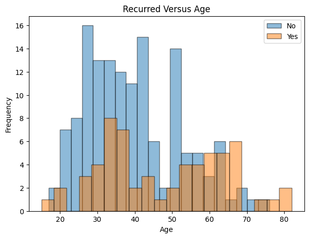

```python
##################################
# Comparing the numeric predictors
# grouped by the target variable
##################################
colors = plt.get_cmap('tab10').colors
plt.figure(figsize=(7, 5))
group_no = thyroid_cancer_train[thyroid_cancer_train[histogram_grouping_variable] == 'No'][histogram_frequency_variable]
group_yes = thyroid_cancer_train[thyroid_cancer_train[histogram_grouping_variable] == 'Yes'][histogram_frequency_variable]
plt.hist(group_no, bins=20, alpha=0.5, color=colors[0], label='No', edgecolor='black')
plt.hist(group_yes, bins=20, alpha=0.5, color=colors[1], label='Yes', edgecolor='black')
plt.title(f'{histogram_grouping_variable} Versus {histogram_frequency_variable}')
plt.xlabel(histogram_frequency_variable)
plt.ylabel('Frequency')
plt.legend()
plt.show()
```

```python
##################################
# Performing a general exploration of the categorical variable levels
# based on the ordered categories
##################################
ordered_cat_cols = thyroid_cancer_train.select_dtypes(include=["category"]).columns
for col in ordered_cat_cols:
    print(f"Column: {col}")
    print("Absolute Frequencies:")
    print(thyroid_cancer_train[col].value_counts().reindex(thyroid_cancer_train[col].cat.categories))
    print("\nNormalized Frequencies:")
    print(thyroid_cancer_train[col].value_counts(normalize=True).reindex(thyroid_cancer_train[col].cat.categories))
    print("-" * 50)
```

```
Column: Gender
Absolute Frequencies:
M     44
F    160
Name: count, dtype: int64

Normalized Frequencies:
M    0.215686
F    0.784314
Name: proportion, dtype: float64
--------------------------------------------------
Column: Smoking
Absolute Frequencies:
No     177
Yes     27
Name: count, dtype: int64

Normalized Frequencies:
No     0.867647
Yes    0.132353
Name: proportion, dtype: float64
--------------------------------------------------
Column: Hx_Smoking
Absolute Frequencies:
No     193
Yes     11
Name: count, dtype: int64

Normalized Frequencies:
No     0.946078
Yes    0.053922
Name: proportion, dtype: float64
--------------------------------------------------
Column: Hx_Radiotherapy
Absolute Frequencies:
No     202
Yes      2
Name: count, dtype: int64

Normalized Frequencies:
```

[output cut: 169 more lines]

```
Biochemical Incomplete    0.039216
Indeterminate             0.166667
Name: proportion, dtype: float64
--------------------------------------------------
Column: Recurred
Absolute Frequencies:
No     143
Yes     61
Name: count, dtype: int64

Normalized Frequencies:
No     0.70098
Yes    0.29902
Name: proportion, dtype: float64
--------------------------------------------------
```

```python
##################################
# Segregating the target variable
# and categorical predictors
##################################
proportion_y_variables = thyroid_cancer_train_predictors_categorical
proportion_x_variable = 'Recurred'
```

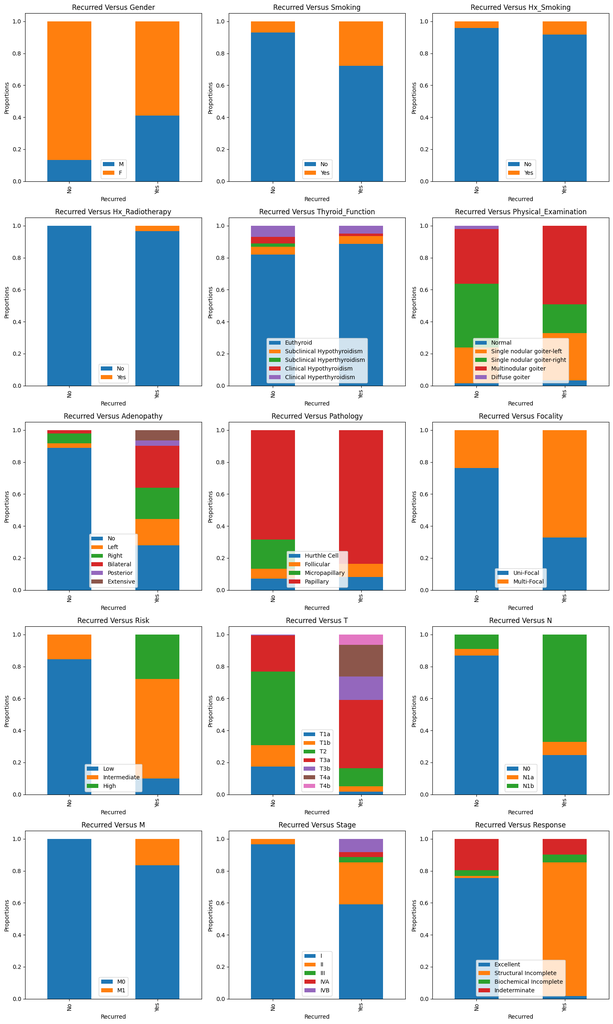

```python
##################################
# Defining the number of
# rows and columns for the subplots
##################################
num_rows = 5
num_cols = 3

##################################
# Formulating the subplot structure
##################################
fig, axes = plt.subplots(num_rows, num_cols, figsize=(15, 25))

##################################
# Flattening the multi-row and
# multi-column axes
##################################
axes = axes.ravel()

##################################
# Formulating the individual stacked column plots
# for all categorical columns
##################################
for i, y_variable in enumerate(proportion_y_variables):
    ax = axes[i]
    category_counts = thyroid_cancer_train.groupby([proportion_x_variable, y_variable], observed=True).size().unstack(fill_value=0)
    category_proportions = category_counts.div(category_counts.sum(axis=1), axis=0)
    category_proportions.plot(kind='bar', stacked=True, ax=ax)
    ax.set_title(f'{proportion_x_variable} Versus {y_variable}')
    ax.set_xlabel(proportion_x_variable)
    ax.set_ylabel('Proportions')
    ax.legend(loc="lower center")

##################################
# Adjusting the subplot layout
##################################
plt.tight_layout()

##################################
# Presenting the subplots
##################################
plt.show()
```

```python
##################################
# Removing predictors observed with extreme
# near-zero variance and a limited number of levels
##################################
thyroid_cancer_train_column_filtered = thyroid_cancer_train.drop(columns=['Hx_Radiotherapy','M','Hx_Smoking'])
thyroid_cancer_train_column_filtered.head()
```

|  | Age | Gender | Smoking | Thyroid_Function | Physical_Examination | Adenopathy | Pathology | Focality | Risk | T | N | Stage | Response | Recurred |
| --- | --- | --- | --- | --- | --- | --- | --- | --- | --- | --- | --- | --- | --- | --- |
| 140 | 28.0 | F | No | Euthyroid | Multinodular goiter | No | Papillary | Uni-Focal | Low | T2 | N0 | I | Excellent | No |
| 205 | 36.0 | F | No | Euthyroid | Single nodular goiter-right | Right | Papillary | Uni-Focal | Low | T2 | N1b | I | Indeterminate | No |
| 277 | 41.0 | M | Yes | Euthyroid | Single nodular goiter-right | No | Hurthle Cell | Multi-Focal | Intermediate | T3a | N0 | I | Excellent | No |
| 294 | 42.0 | M | No | Subclinical Hypothyroidism | Single nodular goiter-right | No | Papillary | Multi-Focal | Intermediate | T3a | N1a | I | Indeterminate | No |
| 268 | 32.0 | F | No | Euthyroid | Single nodular goiter-left | No | Papillary | Uni-Focal | Low | T3a | N0 | I | Excellent | No |

### 1.4.3 Category Aggregation and Encoding

1. Category aggregation was applied to the previously identified categorical predictors observed with many levels (high-cardinality) containing only a few observations to improve model stability during cross-validation and enhance generalization:
   - Thyroid_Function:
     - **171** Thyroid_Function=Euthyroid: 83.82%
     - **33** Thyroid_Function=Hypothyroidism or Hyperthyroidism: 16.18%
   - Physical_Examination:
     - **122** Physical_Examination=Normal or Single Nodular Goiter : 59.80%
     - **82** Physical_Examination=Multinodular or Diffuse Goiter: 40.20%
   - Adenopathy:
     - **144** Adenopathy=No: 70.59%
     - **60** Adenopathy=Yes: 29.41%
   - Pathology:
     - **29** Pathology=Non-Papillary : 14.22%
     - **175** Pathology=Papillary: 85.78%
   - Risk:
     - **127** Risk=Low: 62.25%
     - **77** Risk=Intermediate to High: 37.75%
   - T:
     - **120** T=T1 to T2: 58.82%
     - **84** T=T3 to T4b: 41.18%
   - N:
     - **139** N=N0: 68.14%
     - **65** N=N1: 31.86%
   - Stage:
     - **174** Stage=I: 85.29%
     - **30** Stage=II to IVB: 14.71%
   - Response:
     - **109** Response=Excellent: 53.43%
     - **95** Response=Indeterminate or Incomplete: 46.57%

```python
##################################
# Merging small categories into broader groups
# for certain categorical predictors
# to ensure sufficient representation in statistical models
# and prevent sparsity issues in cross-validation
##################################
thyroid_cancer_train_column_filtered['Thyroid_Function'] = thyroid_cancer_train_column_filtered['Thyroid_Function'].map(lambda x: 'Euthyroid' if (x in ['Euthyroid'])  else 'Hypothyroidism or Hyperthyroidism').astype('category')
thyroid_cancer_train_column_filtered['Physical_Examination'] = thyroid_cancer_train_column_filtered['Physical_Examination'].map(lambda x: 'Normal or Single Nodular Goiter' if (x in ['Normal', 'Single nodular goiter-left', 'Single nodular goiter-right'])  else 'Multinodular or Diffuse Goiter').astype('category')
thyroid_cancer_train_column_filtered['Adenopathy'] = thyroid_cancer_train_column_filtered['Adenopathy'].map(lambda x: 'No' if x == 'No' else ('Yes' if pd.notna(x) and x != '' else x)).astype('category')
thyroid_cancer_train_column_filtered['Pathology'] = thyroid_cancer_train_column_filtered['Pathology'].map(lambda x: 'Non-Papillary' if (x in ['Hurthle Cell', 'Follicular'])  else 'Papillary').astype('category')
thyroid_cancer_train_column_filtered['Risk'] = thyroid_cancer_train_column_filtered['Risk'].map(lambda x: 'Low' if (x in ['Low'])  else 'Intermediate to High').astype('category')
thyroid_cancer_train_column_filtered['T'] = thyroid_cancer_train_column_filtered['T'].map(lambda x: 'T1 to T2' if (x in ['T1a', 'T1b', 'T2'])  else 'T3 to T4b').astype('category')
thyroid_cancer_train_column_filtered['N'] = thyroid_cancer_train_column_filtered['N'].map(lambda x: 'N0' if (x in ['N0'])  else 'N1').astype('category')
thyroid_cancer_train_column_filtered['Stage'] = thyroid_cancer_train_column_filtered['Stage'].map(lambda x: 'I' if (x in ['I'])  else 'II to IVB').astype('category')
thyroid_cancer_train_column_filtered['Response'] = thyroid_cancer_train_column_filtered['Response'].map(lambda x: 'Indeterminate or Incomplete' if (x in ['Indeterminate', 'Structural Incomplete', 'Biochemical Incomplete'])  else 'Excellent').astype('category')
thyroid_cancer_train_column_filtered.head()
```

|  | Age | Gender | Smoking | Thyroid_Function | Physical_Examination | Adenopathy | Pathology | Focality | Risk | T | N | Stage | Response | Recurred |
| --- | --- | --- | --- | --- | --- | --- | --- | --- | --- | --- | --- | --- | --- | --- |
| 140 | 28.0 | F | No | Euthyroid | Multinodular or Diffuse Goiter | No | Papillary | Uni-Focal | Low | T1 to T2 | N0 | I | Excellent | No |
| 205 | 36.0 | F | No | Euthyroid | Normal or Single Nodular Goiter | Yes | Papillary | Uni-Focal | Low | T1 to T2 | N1 | I | Indeterminate or Incomplete | No |
| 277 | 41.0 | M | Yes | Euthyroid | Normal or Single Nodular Goiter | No | Non-Papillary | Multi-Focal | Intermediate to High | T3 to T4b | N0 | I | Excellent | No |
| 294 | 42.0 | M | No | Hypothyroidism or Hyperthyroidism | Normal or Single Nodular Goiter | No | Papillary | Multi-Focal | Intermediate to High | T3 to T4b | N1 | I | Indeterminate or Incomplete | No |
| 268 | 32.0 | F | No | Euthyroid | Normal or Single Nodular Goiter | No | Papillary | Uni-Focal | Low | T3 to T4b | N0 | I | Excellent | No |

```python
##################################
# Performing a general exploration of the categorical variable levels
# based on the ordered categories
##################################
ordered_cat_cols = thyroid_cancer_train_column_filtered.select_dtypes(include=["category"]).columns
for col in ordered_cat_cols:
    print(f"Column: {col}")
    print("Absolute Frequencies:")
    print(thyroid_cancer_train_column_filtered[col].value_counts().reindex(thyroid_cancer_train_column_filtered[col].cat.categories))
    print("\nNormalized Frequencies:")
    print(thyroid_cancer_train_column_filtered[col].value_counts(normalize=True).reindex(thyroid_cancer_train_column_filtered[col].cat.categories))
    print("-" * 50)
```

```
Column: Gender
Absolute Frequencies:
M     44
F    160
Name: count, dtype: int64

Normalized Frequencies:
M    0.215686
F    0.784314
Name: proportion, dtype: float64
--------------------------------------------------
Column: Smoking
Absolute Frequencies:
No     177
Yes     27
Name: count, dtype: int64

Normalized Frequencies:
No     0.867647
Yes    0.132353
Name: proportion, dtype: float64
--------------------------------------------------
Column: Thyroid_Function
Absolute Frequencies:
Euthyroid                            171
Hypothyroidism or Hyperthyroidism     33
Name: count, dtype: int64

Normalized Frequencies:
Euthyroid                            0.838235
Hypothyroidism or Hyperthyroidism    0.161765
Name: proportion, dtype: float64
--------------------------------------------------
Column: Physical_Examination
Absolute Frequencies:
Multinodular or Diffuse Goiter      82
Normal or Single Nodular Goiter    122
Name: count, dtype: int64

Normalized Frequencies:
```

[output cut: 88 more lines]

```
Excellent                      0.534314
Indeterminate or Incomplete    0.465686
Name: proportion, dtype: float64
--------------------------------------------------
Column: Recurred
Absolute Frequencies:
No     143
Yes     61
Name: count, dtype: int64

Normalized Frequencies:
No     0.70098
Yes    0.29902
Name: proportion, dtype: float64
--------------------------------------------------
```

```python
##################################
# Segregating the target
# and predictor variables
##################################
thyroid_cancer_train_predictors = thyroid_cancer_train_column_filtered.iloc[:,:-1].columns
thyroid_cancer_train_predictors_numeric = thyroid_cancer_train_column_filtered.iloc[:,:-1].loc[:, thyroid_cancer_train_column_filtered.iloc[:,:-1].columns == 'Age'].columns
thyroid_cancer_train_predictors_categorical = thyroid_cancer_train_column_filtered.iloc[:,:-1].loc[:,thyroid_cancer_train_column_filtered.iloc[:,:-1].columns != 'Age'].columns
```

```python
##################################
# Segregating the target variable
# and categorical predictors
##################################
proportion_y_variables = thyroid_cancer_train_predictors_categorical
proportion_x_variable = 'Recurred'
```

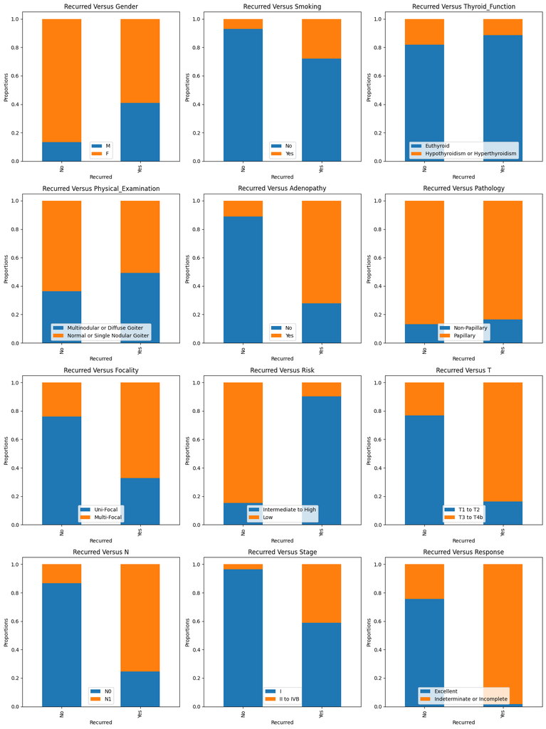

```python
##################################
# Defining the number of
# rows and columns for the subplots
##################################
num_rows = 4
num_cols = 3

##################################
# Formulating the subplot structure
##################################
fig, axes = plt.subplots(num_rows, num_cols, figsize=(15, 20))

##################################
# Flattening the multi-row and
# multi-column axes
##################################
axes = axes.ravel()

##################################
# Formulating the individual stacked column plots
# for all categorical columns
##################################
for i, y_variable in enumerate(proportion_y_variables):
    ax = axes[i]
    category_counts = thyroid_cancer_train_column_filtered.groupby([proportion_x_variable, y_variable], observed=True).size().unstack(fill_value=0)
    category_proportions = category_counts.div(category_counts.sum(axis=1), axis=0)
    category_proportions.plot(kind='bar', stacked=True, ax=ax)
    ax.set_title(f'{proportion_x_variable} Versus {y_variable}')
    ax.set_xlabel(proportion_x_variable)
    ax.set_ylabel('Proportions')
    ax.legend(loc="lower center")

##################################
# Adjusting the subplot layout
##################################
plt.tight_layout()

##################################
# Presenting the subplots
##################################
plt.show()
```

### 1.4.4 Outlier and Distributional Shape Analysis

1. No outliers (Outlier.Count>0, Outlier.Ratio>0.000), high skewness (Skewness>3 or Skewness<(-3)) or abnormal kurtosis (Skewness>2 or Skewness<(-2)) observed for the numeric predictor.
   - Age: Outlier.Count = 0, Outlier.Ratio = 0.000, Skewness = 0.525, Kurtosis = -0.494

```python
##################################
# Formulating the imputed dataset
# with numeric columns only
##################################
thyroid_cancer_train_column_filtered['Age'] = pd.to_numeric(thyroid_cancer_train_column_filtered['Age'])
thyroid_cancer_train_column_filtered_numeric = thyroid_cancer_train_column_filtered.select_dtypes(include='number')
thyroid_cancer_train_column_filtered_numeric = thyroid_cancer_train_column_filtered_numeric.to_frame() if isinstance(thyroid_cancer_train_column_filtered_numeric, pd.Series) else thyroid_cancer_train_column_filtered_numeric
```

```python
##################################
# Gathering the variable names for each numeric column
##################################
numeric_variable_name_list = list(thyroid_cancer_train_column_filtered_numeric.columns)
```

```python
##################################
# Gathering the skewness value for each numeric column
##################################
numeric_skewness_list = thyroid_cancer_train_column_filtered_numeric.skew()
```

```python
##################################
# Computing the interquartile range
# for all columns
##################################
thyroid_cancer_train_column_filtered_numeric_q1 = thyroid_cancer_train_column_filtered_numeric.quantile(0.25)
thyroid_cancer_train_column_filtered_numeric_q3 = thyroid_cancer_train_column_filtered_numeric.quantile(0.75)
thyroid_cancer_train_column_filtered_numeric_iqr = thyroid_cancer_train_column_filtered_numeric_q3 - thyroid_cancer_train_column_filtered_numeric_q1
```

```python
##################################
# Gathering the outlier count for each numeric column
# based on the interquartile range criterion
##################################
numeric_outlier_count_list = ((thyroid_cancer_train_column_filtered_numeric < (thyroid_cancer_train_column_filtered_numeric_q1 - 1.5 * thyroid_cancer_train_column_filtered_numeric_iqr)) | (thyroid_cancer_train_column_filtered_numeric > (thyroid_cancer_train_column_filtered_numeric_q3 + 1.5 * thyroid_cancer_train_column_filtered_numeric_iqr))).sum()
```

```python
##################################
# Gathering the number of observations for each column
##################################
numeric_row_count_list = list([len(thyroid_cancer_train_column_filtered_numeric)] * len(thyroid_cancer_train_column_filtered_numeric.columns))
```

```python
##################################
# Gathering the unique to count ratio for each numeric column
##################################
numeric_outlier_ratio_list = map(truediv, numeric_outlier_count_list, numeric_row_count_list)
```

```python
##################################
# Gathering the skewness value for each numeric column
##################################
numeric_skewness_list = thyroid_cancer_train_column_filtered_numeric.skew()
```

```python
##################################
# Gathering the kurtosis value for each numeric column
##################################
numeric_kurtosis_list = thyroid_cancer_train_column_filtered_numeric.kurtosis()
```

```python
##################################
# Formulating the outlier summary
# for all numeric columns
##################################
numeric_column_outlier_summary = pd.DataFrame(zip(numeric_variable_name_list,
                                                  numeric_skewness_list,
                                                  numeric_outlier_count_list,
                                                  numeric_row_count_list,
                                                  numeric_outlier_ratio_list,
                                                  numeric_skewness_list,
                                                  numeric_kurtosis_list),
                                        columns=['Numeric.Column.Name',
                                                 'Skewness',
                                                 'Outlier.Count',
                                                 'Row.Count',
                                                 'Outlier.Ratio',
                                                 'Skewness',
                                                 'Kurtosis'])
display(numeric_column_outlier_summary)
```

|  | Numeric.Column.Name | Skewness | Outlier.Count | Row.Count | Outlier.Ratio | Skewness | Kurtosis |
| --- | --- | --- | --- | --- | --- | --- | --- |
| 0 | Age | 0.525218 | 0 | 204 | 0.0 | 0.525218 | -0.494286 |

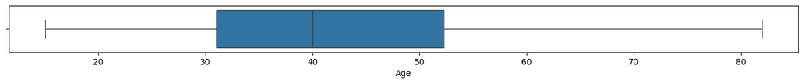

```python
##################################
# Formulating the individual boxplots
# for all numeric columns
##################################
for column in thyroid_cancer_train_column_filtered_numeric:
        plt.figure(figsize=(17,1))
        sns.boxplot(data=thyroid_cancer_train_column_filtered_numeric, x=column)
```

### 1.4.5 Collinearity

1. Majority of the predictors reported low (<0.50) to moderate (0.50 to 0.75) correlation.
2. Among pairwise combinations of categorical predictors, high Phi.Coefficient values were noted for:
   - N and Adenopathy: Phi.Coefficient = +0.805
   - N and Risk: Phi.Coefficient = +0.726
   - Adenopathy and Risk: Phi.Coefficient = +0.674

```python
##################################
# Creating a dataset copy and
# converting all values to numeric
# for correlation analysis
##################################
pd.set_option('future.no_silent_downcasting', True)
thyroid_cancer_train_correlation = thyroid_cancer_train_column_filtered.copy()
thyroid_cancer_train_correlation_object = thyroid_cancer_train_correlation.iloc[:,1:13].columns
custom_category_orders = {
    'Gender': ['M', 'F'],
    'Smoking': ['No', 'Yes'],
    'Thyroid_Function': ['Euthyroid', 'Hypothyroidism or Hyperthyroidism'],
    'Physical_Examination': ['Normal or Single Nodular Goiter', 'Multinodular or Diffuse Goiter'],
    'Adenopathy': ['No', 'Yes'],
    'Pathology': ['Non-Papillary', 'Papillary'],
    'Focality': ['Uni-Focal', 'Multi-Focal'],
    'Risk': ['Low', 'Intermediate to High'],
    'T': ['T1 to T2', 'T3 to T4b'],
    'N': ['N0', 'N1'],
    'Stage': ['I', 'II to IVB'],
    'Response': ['Excellent', 'Indeterminate or Incomplete']
}
encoder = OrdinalEncoder(categories=[custom_category_orders[col] for col in thyroid_cancer_train_correlation_object])
thyroid_cancer_train_correlation[thyroid_cancer_train_correlation_object] = encoder.fit_transform(
    thyroid_cancer_train_correlation[thyroid_cancer_train_correlation_object]
)
thyroid_cancer_train_correlation = thyroid_cancer_train_correlation.drop(['Recurred'], axis=1)
display(thyroid_cancer_train_correlation)
```

|  | Age | Gender | Smoking | Thyroid_Function | Physical_Examination | Adenopathy | Pathology | Focality | Risk | T | N | Stage | Response |
| --- | --- | --- | --- | --- | --- | --- | --- | --- | --- | --- | --- | --- | --- |
| 140 | 28.0 | 1.0 | 0.0 | 0.0 | 1.0 | 0.0 | 1.0 | 0.0 | 0.0 | 0.0 | 0.0 | 0.0 | 0.0 |
| 205 | 36.0 | 1.0 | 0.0 | 0.0 | 0.0 | 1.0 | 1.0 | 0.0 | 0.0 | 0.0 | 1.0 | 0.0 | 1.0 |
| 277 | 41.0 | 0.0 | 1.0 | 0.0 | 0.0 | 0.0 | 0.0 | 1.0 | 1.0 | 1.0 | 0.0 | 0.0 | 0.0 |
| 294 | 42.0 | 0.0 | 0.0 | 1.0 | 0.0 | 0.0 | 1.0 | 1.0 | 1.0 | 1.0 | 1.0 | 0.0 | 1.0 |
| 268 | 32.0 | 1.0 | 0.0 | 0.0 | 0.0 | 0.0 | 1.0 | 0.0 | 0.0 | 1.0 | 0.0 | 0.0 | 0.0 |
| ... | ... | ... | ... | ... | ... | ... | ... | ... | ... | ... | ... | ... | ... |
| 300 | 67.0 | 1.0 | 0.0 | 0.0 | 1.0 | 0.0 | 0.0 | 0.0 | 1.0 | 1.0 | 0.0 | 1.0 | 1.0 |
| 115 | 37.0 | 1.0 | 0.0 | 0.0 | 0.0 | 0.0 | 1.0 | 0.0 | 0.0 | 0.0 | 0.0 | 0.0 | 0.0 |
| 67 | 51.0 | 1.0 | 0.0 | 0.0 | 0.0 | 0.0 | 1.0 | 0.0 | 0.0 | 0.0 | 0.0 | 0.0 | 0.0 |
| 161 | 22.0 | 1.0 | 0.0 | 0.0 | 0.0 | 0.0 | 1.0 | 0.0 | 0.0 | 0.0 | 0.0 | 0.0 | 0.0 |
| 55 | 21.0 | 1.0 | 0.0 | 0.0 | 0.0 | 0.0 | 1.0 | 0.0 | 0.0 | 0.0 | 0.0 | 0.0 | 1.0 |

204 rows × 13 columns

```python
##################################
# Initializing the correlation matrix
##################################
thyroid_cancer_train_correlation_matrix = pd.DataFrame(np.zeros((len(thyroid_cancer_train_correlation.columns), len(thyroid_cancer_train_correlation.columns))),
                                                       columns=thyroid_cancer_train_correlation.columns,
                                                       index=thyroid_cancer_train_correlation.columns)
```

```python
##################################
# Creating an empty correlation matrix
##################################
thyroid_cancer_train_correlation_matrix = pd.DataFrame(
    np.zeros((len(thyroid_cancer_train_correlation.columns), len(thyroid_cancer_train_correlation.columns))),
    index=thyroid_cancer_train_correlation.columns,
    columns=thyroid_cancer_train_correlation.columns
)


##################################
# Calculating different types
# of correlation coefficients
# per variable type
##################################
for i in range(len(thyroid_cancer_train_correlation.columns)):
    for j in range(i, len(thyroid_cancer_train_correlation.columns)):
        if i == j:
            thyroid_cancer_train_correlation_matrix.iloc[i, j] = 1.0
        else:
            col_i = thyroid_cancer_train_correlation.iloc[:, i]
            col_j = thyroid_cancer_train_correlation.iloc[:, j]

            # Detecting binary variables (assumes binary variables are coded as 0/1)
            is_binary_i = col_i.nunique() == 2
            is_binary_j = col_j.nunique() == 2

            # Computing the Pearson correlation for two continuous variables
            if col_i.dtype in ['int64', 'float64'] and col_j.dtype in ['int64', 'float64']:
                corr = col_i.corr(col_j)

            # Computing the Point-Biserial correlation for continuous and binary variables
            elif (col_i.dtype in ['int64', 'float64'] and is_binary_j) or (col_j.dtype in ['int64', 'float64'] and is_binary_i):
                continuous_var = col_i if col_i.dtype in ['int64', 'float64'] else col_j
                binary_var = col_j if is_binary_j else col_i

                # Convert binary variable to 0/1 (if not already)
                binary_var = binary_var.astype('category').cat.codes
                corr, _ = pointbiserialr(continuous_var, binary_var)

            # Computing the Phi coefficient for two binary variables
            elif is_binary_i and is_binary_j:
                corr = col_i.corr(col_j)

            # Computing the Cramér's V for two categorical variables (if more than 2 categories)
            else:
                contingency_table = pd.crosstab(col_i, col_j)
                chi2, _, _, _ = chi2_contingency(contingency_table)
                n = contingency_table.sum().sum()
                phi2 = chi2 / n
                r, k = contingency_table.shape
                corr = np.sqrt(phi2 / min(k - 1, r - 1))  # Cramér's V formula

            # Assigning correlation values to the matrix
            thyroid_cancer_train_correlation_matrix.iloc[i, j] = corr
            thyroid_cancer_train_correlation_matrix.iloc[j, i] = corr

# Displaying the correlation matrix
display(thyroid_cancer_train_correlation_matrix)
```

|  | Age | Gender | Smoking | Thyroid_Function | Physical_Examination | Adenopathy | Pathology | Focality | Risk | T | N | Stage | Response |
| --- | --- | --- | --- | --- | --- | --- | --- | --- | --- | --- | --- | --- | --- |
| Age | 1.000000 | -0.185530 | 0.299971 | 0.077845 | 0.012021 | 0.073931 | -0.215274 | 0.195272 | 0.205360 | 0.246838 | 0.013195 | 0.528144 | 0.317978 |
| Gender | -0.185530 | 1.000000 | -0.604101 | -0.093290 | -0.031935 | -0.158480 | 0.127817 | -0.218103 | -0.255507 | -0.215101 | -0.178550 | -0.219727 | -0.179431 |
| Smoking | 0.299971 | -0.604101 | 1.000000 | 0.064124 | 0.004339 | 0.192350 | -0.338086 | 0.182212 | 0.233024 | 0.231679 | 0.105463 | 0.327952 | 0.215362 |
| Thyroid_Function | 0.077845 | -0.093290 | 0.064124 | 1.000000 | 0.019964 | -0.137486 | -0.049893 | 0.051564 | -0.012519 | -0.042960 | -0.043275 | 0.080702 | -0.036498 |
| Physical_Examination | 0.012021 | -0.031935 | 0.004339 | 0.019964 | 1.000000 | 0.063246 | 0.018806 | 0.245779 | 0.166012 | 0.086039 | 0.104553 | 0.054799 | 0.116526 |
| Adenopathy | 0.073931 | -0.158480 | 0.192350 | -0.137486 | 0.063246 | 1.000000 | 0.047117 | 0.288750 | 0.673638 | 0.421762 | 0.805406 | 0.278749 | 0.518887 |
| Pathology | -0.215274 | 0.127817 | -0.338086 | -0.049893 | 0.018806 | 0.047117 | 1.000000 | -0.126299 | -0.117392 | -0.286899 | 0.157869 | -0.187683 | -0.154637 |
| Focality | 0.195272 | -0.218103 | 0.182212 | 0.051564 | 0.245779 | 0.288750 | -0.126299 | 1.000000 | 0.454926 | 0.518864 | 0.307716 | 0.372331 | 0.388741 |
| Risk | 0.205360 | -0.255507 | 0.233024 | -0.012519 | 0.166012 | 0.673638 | -0.117392 | 0.454926 | 1.000000 | 0.622459 | 0.726304 | 0.533264 | 0.631330 |
| T | 0.246838 | -0.215101 | 0.231679 | -0.042960 | 0.086039 | 0.421762 | -0.286899 | 0.518864 | 0.622459 | 1.000000 | 0.368430 | 0.468168 | 0.556742 |
| N | 0.013195 | -0.178550 | 0.105463 | -0.043275 | 0.104553 | 0.805406 | 0.157869 | 0.307716 | 0.726304 | 0.368430 | 1.000000 | 0.310156 | 0.542672 |
| Stage | 0.528144 | -0.219727 | 0.327952 | 0.080702 | 0.054799 | 0.278749 | -0.187683 | 0.372331 | 0.533264 | 0.468168 | 0.310156 | 1.000000 | 0.417025 |
| Response | 0.317978 | -0.179431 | 0.215362 | -0.036498 | 0.116526 | 0.518887 | -0.154637 | 0.388741 | 0.631330 | 0.556742 | 0.542672 | 0.417025 | 1.000000 |

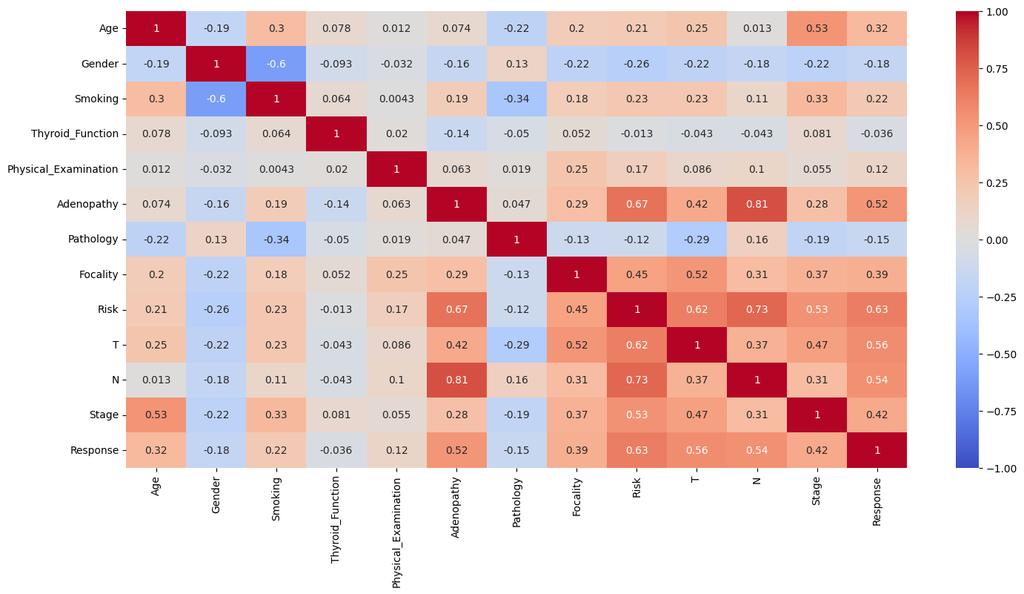

```python
##################################
# Plotting the correlation matrix
# for all pairwise combinations
# of numeric and categorical columns
##################################
plt.figure(figsize=(17, 8))
sns.heatmap(thyroid_cancer_train_correlation_matrix, annot=True, cmap='coolwarm', vmin=-1, vmax=1)
plt.show()
```

## 1.5. Data Exploration

### 1.5.1 Exploratory Data Analysis

1. Bivariate analysis identified individual predictors with generally positive association to the target variable based on visual inspection.
2. Higher values or higher proportions for the following predictors are associated with the Recurred=Yes category:
   - Age
   - Gender=M
   - Smoking=Yes
   - Physical_Examination=Multinodular or Diffuse Goiter
   - Adenopathy=Yes
   - Focality=Multi-Focal
   - Risk=Intermediate to High
   - T=T3 to T4b
   - N=N1
   - Stage=II to IVB
   - Response=Indeterminate or Incomplete
3. Proportions for the following predictors are not associated with the Recurred=Yes or Recurred=No categories:
   - Thyroid_Function
   - Pathology

```python
##################################
# Segregating the target
# and predictor variables
##################################
thyroid_cancer_train_column_filtered_predictors = thyroid_cancer_train_column_filtered.iloc[:,:-1].columns
thyroid_cancer_train_column_filtered_predictors_numeric = thyroid_cancer_train_column_filtered.iloc[:,:-1].loc[:, thyroid_cancer_train_column_filtered.iloc[:,:-1].columns == 'Age'].columns
thyroid_cancer_train_column_filtered_predictors_categorical = thyroid_cancer_train_column_filtered.iloc[:,:-1].loc[:,thyroid_cancer_train_column_filtered.iloc[:,:-1].columns != 'Age'].columns
```

```python
##################################
# Gathering the variable names for each numeric column
##################################
numeric_variable_name_list = thyroid_cancer_train_column_filtered_predictors_numeric
```

```python
##################################
# Segregating the target variable
# and numeric predictors
##################################
boxplot_y_variable = 'Recurred'
boxplot_x_variable = numeric_variable_name_list.values[0]
```

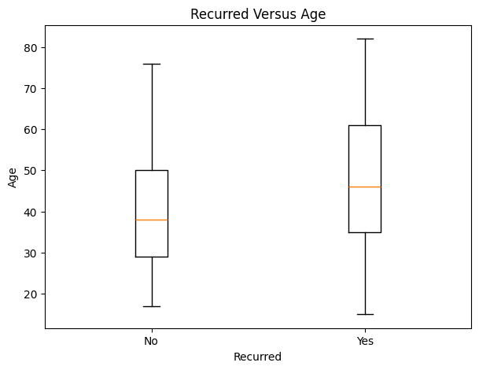

```python
##################################
# Evaluating the numeric predictors
# against the target variable
##################################
plt.figure(figsize=(7, 5))
plt.boxplot([group[boxplot_x_variable] for name, group in thyroid_cancer_train_column_filtered.groupby(boxplot_y_variable, observed=True)])
plt.title(f'{boxplot_y_variable} Versus {boxplot_x_variable}')
plt.xlabel(boxplot_y_variable)
plt.ylabel(boxplot_x_variable)
plt.xticks(range(1, len(thyroid_cancer_train_column_filtered[boxplot_y_variable].unique()) + 1), ['No', 'Yes'])
plt.show()
```

```python
##################################
# Segregating the target variable
# and categorical predictors
##################################
proportion_y_variables = thyroid_cancer_train_column_filtered_predictors_categorical
proportion_x_variable = 'Recurred'
```

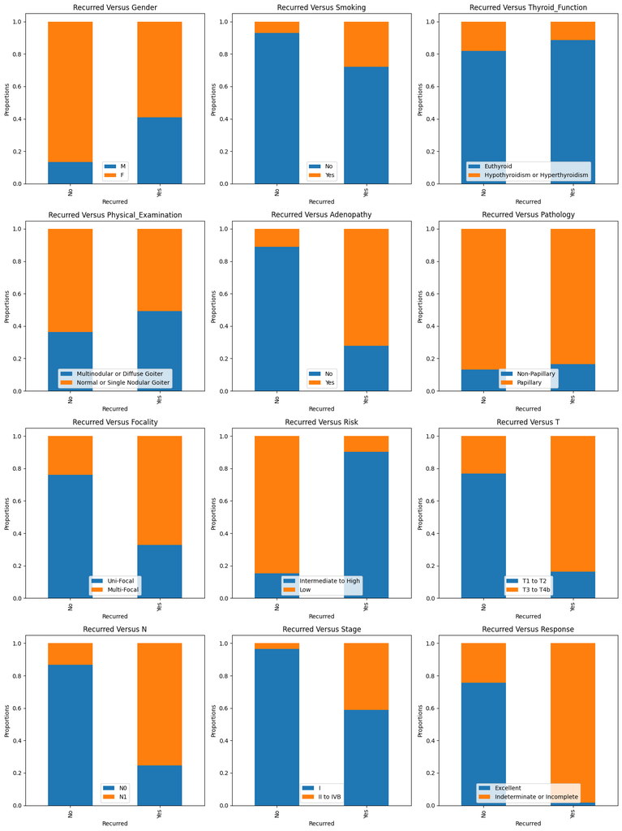

```python
##################################
# Defining the number of
# rows and columns for the subplots
##################################
num_rows = 4
num_cols = 3

##################################
# Formulating the subplot structure
##################################
fig, axes = plt.subplots(num_rows, num_cols, figsize=(15, 20))

##################################
# Flattening the multi-row and
# multi-column axes
##################################
axes = axes.ravel()

##################################
# Formulating the individual stacked column plots
# for all categorical columns
##################################
for i, y_variable in enumerate(proportion_y_variables):
    ax = axes[i]
    category_counts = thyroid_cancer_train_column_filtered.groupby([proportion_x_variable, y_variable], observed=True).size().unstack(fill_value=0)
    category_proportions = category_counts.div(category_counts.sum(axis=1), axis=0)
    category_proportions.plot(kind='bar', stacked=True, ax=ax)
    ax.set_title(f'{proportion_x_variable} Versus {y_variable}')
    ax.set_xlabel(proportion_x_variable)
    ax.set_ylabel('Proportions')
    ax.legend(loc="lower center")

##################################
# Adjusting the subplot layout
##################################
plt.tight_layout()

##################################
# Presenting the subplots
##################################
plt.show()
```

### 1.5.2 Hypothesis Testing

```python
##################################
# Computing the t-test
# statistic and p-values
# between the target variable
# and numeric predictor columns
##################################
thyroid_cancer_numeric_ttest_target = {}
thyroid_cancer_numeric = thyroid_cancer_train_column_filtered.loc[:,(thyroid_cancer_train_column_filtered.columns == 'Age') | (thyroid_cancer_train_column_filtered.columns == 'Recurred')]
thyroid_cancer_numeric_columns = thyroid_cancer_train_column_filtered_predictors_numeric
for numeric_column in thyroid_cancer_numeric_columns:
    group_0 = thyroid_cancer_numeric[thyroid_cancer_numeric.loc[:,'Recurred']=='No']
    group_1 = thyroid_cancer_numeric[thyroid_cancer_numeric.loc[:,'Recurred']=='Yes']
    thyroid_cancer_numeric_ttest_target['Recurred_' + numeric_column] = stats.ttest_ind(
        group_0[numeric_column],
        group_1[numeric_column],
        equal_var=True)
```

```python
##################################
# Formulating the pairwise ttest summary
# between the target variable
# and numeric predictor columns
##################################
thyroid_cancer_numeric_summary = thyroid_cancer_numeric.from_dict(thyroid_cancer_numeric_ttest_target, orient='index')
thyroid_cancer_numeric_summary.columns = ['T.Test.Statistic', 'T.Test.PValue']
display(thyroid_cancer_numeric_summary.sort_values(by=['T.Test.PValue'], ascending=True).head(len(thyroid_cancer_train_column_filtered_predictors_numeric)))
```

|  | T.Test.Statistic | T.Test.PValue |
| --- | --- | --- |
| Recurred_Age | -3.747942 | 0.000233 |

```python
##################################
# Computing the chisquare
# statistic and p-values
# between the target variable
# and categorical predictor columns
##################################
thyroid_cancer_categorical_chisquare_target = {}
thyroid_cancer_categorical = thyroid_cancer_train_column_filtered.loc[:,(thyroid_cancer_train_column_filtered.columns != 'Age') | (thyroid_cancer_train_column_filtered.columns == 'Recurred')]
thyroid_cancer_categorical_columns = thyroid_cancer_train_column_filtered_predictors_categorical
for categorical_column in thyroid_cancer_categorical_columns:
    contingency_table = pd.crosstab(thyroid_cancer_categorical[categorical_column],
                                    thyroid_cancer_categorical['Recurred'])
    thyroid_cancer_categorical_chisquare_target['Recurred_' + categorical_column] = stats.chi2_contingency(
        contingency_table)[0:2]
```

```python
##################################
# Formulating the pairwise chisquare summary
# between the target variable
# and categorical predictor columns
##################################
thyroid_cancer_categorical_summary = thyroid_cancer_categorical.from_dict(thyroid_cancer_categorical_chisquare_target, orient='index')
thyroid_cancer_categorical_summary.columns = ['ChiSquare.Test.Statistic', 'ChiSquare.Test.PValue']
display(thyroid_cancer_categorical_summary.sort_values(by=['ChiSquare.Test.PValue'], ascending=True).head(len(thyroid_cancer_train_column_filtered_predictors_categorical)))
```

|  | ChiSquare.Test.Statistic | ChiSquare.Test.PValue |
| --- | --- | --- |
| Recurred_Risk | 98.599608 | 3.090804e-23 |
| Recurred_Response | 90.866461 | 1.537030e-21 |
| Recurred_Adenopathy | 73.585561 | 9.636704e-18 |
| Recurred_N | 73.176134 | 1.185810e-17 |
| Recurred_T | 62.205367 | 3.094435e-15 |
| Recurred_Stage | 44.963917 | 2.006987e-11 |
| Recurred_Focality | 32.859398 | 9.907099e-09 |
| Recurred_Gender | 17.787641 | 2.469824e-05 |
| Recurred_Smoking | 14.460357 | 1.431406e-04 |
| Recurred_Physical_Examination | 2.413115 | 1.203227e-01 |
| Recurred_Thyroid_Function | 0.966826 | 3.254729e-01 |
| Recurred_Pathology | 0.131614 | 7.167646e-01 |

## 1.6. Premodelling Data Preparation

### 1.6.2 Preprocessing Pipeline Development

1. A preprocessing pipeline was formulated and applied to the **train data (final)**, **validation data** and **test data** with the following actions:
   - Excluded specified columns noted with low variance, high collinearity and weak predictive power
   - Aggregated categories in multiclass categorical variables into binary levels
   - Converted categorical columns to the appropriate type
   - Set the order of category levels for ordinal encoding during modeling pipeline creation

```python
##################################
# Formulating a preprocessing pipeline
# that removes the specified columns,
# aggregates categories in multiclass categorical variables,
# converts categorical columns to the appropriate type, and
# sets the order of category levels
##################################
def preprocess_dataset(df):
    # Removing the specified columns
    columns_to_remove = ['Hx_Smoking', 'Hx_Radiotherapy', 'M', 'N', 'Thyroid_Function', 'Pathology']
    df = df.drop(columns=columns_to_remove)

    # Applying category aggregation
    df['Physical_Examination'] = df['Physical_Examination'].map(
        lambda x: 'Normal or Single Nodular Goiter' if x in ['Normal', 'Single nodular goiter-left', 'Single nodular goiter-right']
        else 'Multinodular or Diffuse Goiter').astype('category')

    df['Adenopathy'] = df['Adenopathy'].map(
        lambda x: 'No' if x == 'No' else ('Yes' if pd.notna(x) and x != '' else x)).astype('category')

    df['Risk'] = df['Risk'].map(
        lambda x: 'Low' if x == 'Low' else 'Intermediate to High').astype('category')

    df['T'] = df['T'].map(
        lambda x: 'T1 to T2' if x in ['T1a', 'T1b', 'T2'] else 'T3 to T4b').astype('category')

    df['Stage'] = df['Stage'].map(
        lambda x: 'I' if x == 'I' else 'II to IVB').astype('category')

    df['Response'] = df['Response'].map(
        lambda x: 'Indeterminate or Incomplete' if x in ['Indeterminate', 'Structural Incomplete', 'Biochemical Incomplete']
        else 'Excellent').astype('category')

    # Setting category levels
    category_mappings = {
        'Gender': ['M', 'F'],
        'Smoking': ['No', 'Yes'],
        'Physical_Examination': ['Normal or Single Nodular Goiter', 'Multinodular or Diffuse Goiter'],
        'Adenopathy': ['No', 'Yes'],
        'Focality': ['Uni-Focal', 'Multi-Focal'],
        'Risk': ['Low', 'Intermediate to High'],
        'T': ['T1 to T2', 'T3 to T4b'],
        'Stage': ['I', 'II to IVB'],
        'Response': ['Excellent', 'Indeterminate or Incomplete']
    }

    for col, categories in category_mappings.items():
        df[col] = df[col].astype('category')
        df[col] = df[col].cat.set_categories(categories, ordered=True)

    return df
```

```python
##################################
# Applying the preprocessing pipeline
# to the train data
##################################
thyroid_cancer_preprocessed_train = preprocess_dataset(thyroid_cancer_train)
X_preprocessed_train = thyroid_cancer_preprocessed_train.drop('Recurred', axis = 1)
y_preprocessed_train = thyroid_cancer_preprocessed_train['Recurred']
thyroid_cancer_preprocessed_train.to_csv(os.path.join("..", DATASETS_PREPROCESSED_TRAIN_PATH, "thyroid_cancer_preprocessed_train.csv"), index=False)
X_preprocessed_train.to_csv(os.path.join("..", DATASETS_PREPROCESSED_TRAIN_FEATURES_PATH, "X_preprocessed_train.csv"), index=False)
y_preprocessed_train.to_csv(os.path.join("..", DATASETS_PREPROCESSED_TRAIN_TARGET_PATH, "y_preprocessed_train.csv"), index=False)
train_csv_path = os.path.join("..", DATASETS_PREPROCESSED_TRAIN_PATH, "thyroid_cancer_preprocessed_train.csv")
print('Final Preprocessed Train Dataset Dimensions: ')
display(X_preprocessed_train.shape)
display(y_preprocessed_train.shape)
print('Final Preprocessed Train Target Variable Breakdown: ')
display(y_preprocessed_train.value_counts())
print('Final Preprocessed Train Target Variable Proportion: ')
display(y_preprocessed_train.value_counts(normalize = True))
thyroid_cancer_preprocessed_train.head()
```

```
Final Preprocessed Train Dataset Dimensions:
```

```
(204, 10)
```

```
(204,)
```

```
Final Preprocessed Train Target Variable Breakdown:
```

```
Recurred
No     143
Yes     61
Name: count, dtype: int64
```

```
Final Preprocessed Train Target Variable Proportion:
```

```
Recurred
No     0.70098
Yes    0.29902
Name: proportion, dtype: float64
```

|  | Age | Gender | Smoking | Physical_Examination | Adenopathy | Focality | Risk | T | Stage | Response | Recurred |
| --- | --- | --- | --- | --- | --- | --- | --- | --- | --- | --- | --- |
| 140 | 28.0 | F | No | Multinodular or Diffuse Goiter | No | Uni-Focal | Low | T1 to T2 | I | Excellent | No |
| 205 | 36.0 | F | No | Normal or Single Nodular Goiter | Yes | Uni-Focal | Low | T1 to T2 | I | Indeterminate or Incomplete | No |
| 277 | 41.0 | M | Yes | Normal or Single Nodular Goiter | No | Multi-Focal | Intermediate to High | T3 to T4b | I | Excellent | No |
| 294 | 42.0 | M | No | Normal or Single Nodular Goiter | No | Multi-Focal | Intermediate to High | T3 to T4b | I | Indeterminate or Incomplete | No |
| 268 | 32.0 | F | No | Normal or Single Nodular Goiter | No | Uni-Focal | Low | T3 to T4b | I | Excellent | No |

```python
##################################
# Applying the preprocessing pipeline
# to the validation data
##################################
thyroid_cancer_preprocessed_validation = preprocess_dataset(thyroid_cancer_validation)
X_preprocessed_validation = thyroid_cancer_preprocessed_validation.drop('Recurred', axis = 1)
y_preprocessed_validation = thyroid_cancer_preprocessed_validation['Recurred']
thyroid_cancer_preprocessed_validation.to_csv(os.path.join("..", DATASETS_PREPROCESSED_VALIDATION_PATH, "thyroid_cancer_preprocessed_validation.csv"), index=False)
X_preprocessed_validation.to_csv(os.path.join("..", DATASETS_PREPROCESSED_VALIDATION_FEATURES_PATH, "X_preprocessed_validation.csv"), index=False)
y_preprocessed_validation.to_csv(os.path.join("..", DATASETS_PREPROCESSED_VALIDATION_TARGET_PATH, "y_preprocessed_validation.csv"), index=False)
validation_csv_path = os.path.join("..", DATASETS_PREPROCESSED_VALIDATION_PATH, "thyroid_cancer_preprocessed_validation.csv")
print('Final Preprocessed Validation Dataset Dimensions: ')
display(X_preprocessed_validation.shape)
display(y_preprocessed_validation.shape)
print('Final Preprocessed Validation Target Variable Breakdown: ')
display(y_preprocessed_validation.value_counts())
print('Final Preprocessed Validation Target Variable Proportion: ')
display(y_preprocessed_validation.value_counts(normalize = True))
thyroid_cancer_preprocessed_validation.head()
```

```
Final Preprocessed Validation Dataset Dimensions:
```

```
(69, 10)
```

```
(69,)
```

```
Final Preprocessed Validation Target Variable Breakdown:
```

```
Recurred
No     49
Yes    20
Name: count, dtype: int64
```

```
Final Preprocessed Validation Target Variable Proportion:
```

```
Recurred
No     0.710145
Yes    0.289855
Name: proportion, dtype: float64
```

|  | Age | Gender | Smoking | Physical_Examination | Adenopathy | Focality | Risk | T | Stage | Response | Recurred |
| --- | --- | --- | --- | --- | --- | --- | --- | --- | --- | --- | --- |
| 173 | 30.0 | F | No | Normal or Single Nodular Goiter | No | Uni-Focal | Low | T1 to T2 | I | Indeterminate or Incomplete | No |
| 164 | 29.0 | F | No | Normal or Single Nodular Goiter | No | Multi-Focal | Low | T1 to T2 | I | Excellent | No |
| 256 | 21.0 | M | Yes | Normal or Single Nodular Goiter | No | Uni-Focal | Low | T3 to T4b | I | Indeterminate or Incomplete | No |
| 348 | 58.0 | F | No | Multinodular or Diffuse Goiter | Yes | Multi-Focal | Intermediate to High | T3 to T4b | II to IVB | Indeterminate or Incomplete | Yes |
| 131 | 31.0 | F | No | Normal or Single Nodular Goiter | No | Uni-Focal | Low | T1 to T2 | I | Excellent | No |

```python
##################################
# Applying the preprocessing pipeline
# to the test data
##################################
thyroid_cancer_preprocessed_test = preprocess_dataset(thyroid_cancer_test)
X_preprocessed_test = thyroid_cancer_preprocessed_test.drop('Recurred', axis = 1)
y_preprocessed_test = thyroid_cancer_preprocessed_test['Recurred']
thyroid_cancer_preprocessed_test.to_csv(os.path.join("..", DATASETS_PREPROCESSED_TEST_PATH, "thyroid_cancer_preprocessed_test.csv"), index=False)
X_preprocessed_test.to_csv(os.path.join("..", DATASETS_PREPROCESSED_TEST_FEATURES_PATH, "X_preprocessed_test.csv"), index=False)
y_preprocessed_test.to_csv(os.path.join("..", DATASETS_PREPROCESSED_TEST_TARGET_PATH, "y_preprocessed_test.csv"), index=False)
print('Final Preprocessed Test Dataset Dimensions: ')
display(X_preprocessed_test.shape)
display(y_preprocessed_test.shape)
print('Final Preprocessed Test Target Variable Breakdown: ')
display(y_preprocessed_test.value_counts())
print('Final Preprocessed Test Target Variable Proportion: ')
display(y_preprocessed_test.value_counts(normalize = True))
thyroid_cancer_preprocessed_test.head()
```

```
Final Preprocessed Test Dataset Dimensions:
```

```
(91, 10)
```

```
(91,)
```

```
Final Preprocessed Test Target Variable Breakdown:
```

```
Recurred
No     64
Yes    27
Name: count, dtype: int64
```

```
Final Preprocessed Test Target Variable Proportion:
```

```
Recurred
No     0.703297
Yes    0.296703
Name: proportion, dtype: float64
```

|  | Age | Gender | Smoking | Physical_Examination | Adenopathy | Focality | Risk | T | Stage | Response | Recurred |
| --- | --- | --- | --- | --- | --- | --- | --- | --- | --- | --- | --- |
| 345 | 25.0 | F | No | Multinodular or Diffuse Goiter | Yes | Multi-Focal | Intermediate to High | T3 to T4b | I | Indeterminate or Incomplete | Yes |
| 249 | 46.0 | F | No | Normal or Single Nodular Goiter | No | Multi-Focal | Low | T3 to T4b | I | Excellent | No |
| 83 | 40.0 | F | No | Normal or Single Nodular Goiter | No | Uni-Focal | Intermediate to High | T1 to T2 | I | Excellent | No |
| 184 | 67.0 | F | No | Normal or Single Nodular Goiter | No | Uni-Focal | Low | T1 to T2 | I | Excellent | No |
| 146 | 25.0 | F | No | Multinodular or Diffuse Goiter | No | Uni-Focal | Low | T1 to T2 | I | Indeterminate or Incomplete | No |

```python
##################################
# Defining a function to compute
# model performance
##################################
def model_performance_evaluation(y_true, y_pred):
    metric_name = ['Accuracy','Precision','Recall','F1','AUROC']
    metric_value = [accuracy_score(y_true, y_pred),
                   precision_score(y_true, y_pred),
                   recall_score(y_true, y_pred),
                   f1_score(y_true, y_pred),
                   roc_auc_score(y_true, y_pred)]
    metric_summary = pd.DataFrame(zip(metric_name, metric_value),
                                  columns=['metric_name','metric_value'])
    return(metric_summary)
```

```python
##################################
# Defining a function to compute
# model performance
##################################
def evaluate_binary_metrics(y_true, y_pred):
    acc = accuracy_score(y_true, y_pred)
    f1 = f1_score(y_true, y_pred)
    recall = recall_score(y_true, y_pred)  # Sensitivity
    tn, fp, fn, tp = confusion_matrix(y_true, y_pred).ravel()
    specificity = tn / (tn + fp) if (tn + fp) > 0 else 0
    return {'accuracy': acc, 'sensitivity': recall, 'specificity': specificity, 'f1': f1}
```

```python
##################################
# Defining a function to
# create a hash representing a specific experiment configuration
##################################
def generate_run_hash(params: dict, mccv_seed: int) -> str:
    signature = {
        "params": params,
        "mccv_seed": mccv_seed  # ensures same splits produce same hash
    }
    run_string = json.dumps(signature, sort_keys=True)
    return hashlib.md5(run_string.encode("utf-8")).hexdigest()
```

```python
##################################
# Defining a function to
# add utility to search MLflow for a matching hash
##################################
def find_existing_run_by_hash(experiment_name: str, run_hash: str):
    client = MlflowClient()
    experiment = client.get_experiment_by_name(experiment_name)
    if not experiment:
        return None
    runs = client.search_runs(experiment_ids=[experiment.experiment_id])
    for run in runs:
        if run.data.tags.get("run_hash") == run_hash:
            return run.info.run_id
    return None
```

```python
##################################
# Defining a function to
# delete an existing MlFlow run before logging and
# keeping only the latest
##################################
def delete_run(run_id: str):
    client = MlflowClient()
    client.set_terminated(run_id, status="KILLED")
    client.delete_run(run_id)
```

```python
##################################
# Defining a function to
# delete all MLflow runs in an experiment
# in case needed
##################################
def delete_all_runs_in_experiment(experiment_name: str):
    client = MlflowClient()
    experiment = client.get_experiment_by_name(experiment_name)

    if experiment is None:
        print(f"No experiment found with name '{experiment_name}'")
        return

    experiment_id = experiment.experiment_id
    runs = client.search_runs([experiment_id], max_results=10000)

    if not runs:
        print(f"No runs found in experiment '{experiment_name}'")
        return

    print(f"Found {len(runs)} runs in experiment '{experiment_name}'. Deleting...")

    for run in runs:
        run_id = run.info.run_id
        client.set_terminated(run_id, status="KILLED")  # Optional, but safe
        client.delete_run(run_id)

    print("All runs deleted.")
```

```python
##################################
# Defining a function to
# completely remove the MLflow experiment
# including the name and all metadata
##################################
def remove_experiment_name_metadata(experiment_name: str):
    client = MlflowClient()
    experiment = client.get_experiment_by_name(experiment_name)
    if experiment:
        client.delete_experiment(experiment.experiment_id)
        print(f"Deleted experiment '{experiment.name}'.")
```

```python
##################################
# Defining a function to
# generate a confusion matrix
# and log as an MLflow artifact
##################################
def log_confusion_matrix(y_true, y_pred, labels, output_path):
    cm = confusion_matrix(y_true, y_pred, labels=labels)
    plt.figure(figsize=(6, 5))
    sns.heatmap(cm, annot=True, fmt='d', cmap='Blues',
                xticklabels=labels, yticklabels=labels)
    plt.xlabel('Predicted')
    plt.ylabel('True')
    plt.title('Confusion Matrix')
    plt.tight_layout()
    plt.savefig(output_path)
    plt.close()
```

```python
##################################
# Defining a function to
# generate a classification report
# and log as an MLflow artifact
##################################
def log_classification_report(y_true, y_pred, labels, output_path):
    report = classification_report(y_true, y_pred, target_names=[str(l) for l in labels])
    with open(output_path, 'w') as f:
        f.write(report)
```

## 1.7. Ensemble Model Development, Logging and Tracking using the MLflow Framework

### 1.7.1 Random Forest

[Random Forest](https://scikit-learn.org/stable/modules/generated/sklearn.ensemble.RandomForestClassifier.html) is an ensemble learning method that builds multiple decision trees and combines their outputs to improve prediction accuracy and robustness in binary classification. Instead of relying on a single decision tree, it aggregates multiple trees, reducing overfitting and increasing generalizability. The algorithm works by training individual decision trees on bootstrapped samples of the dataset, where each tree is trained on a slightly different subset of data. Additionally, at each decision node, a random subset of features is considered for splitting, adding further diversity among the trees. The final classification is determined by majority voting across all trees. The main advantages of Random Forest include its resilience to overfitting, ability to handle high-dimensional data, and robustness against noisy data. However, it has limitations, such as higher computational cost due to multiple trees and reduced interpretability compared to a single decision tree. It can also struggle with highly imbalanced data unless additional techniques like class weighting are applied.

1. The [random forest](https://scikit-learn.org/stable/modules/generated/sklearn.ensemble.RandomForestClassifier.html) model from the **sklearn.ensemble** Python library API was implemented. Combined with a preprocessing operation into a pipeline, the **mlflow.sklearn** module was used for loading and logging the model during experiment tracking.
2. The model contains 4 hyperparameters for tuning:
   - criterion = function to measure the quality of a split made to vary between gini and entropy
   - max_depth = maximum depth of the tree made to vary between 3 and 6
   - min_samples_leaf = minimum number of samples required to be at a leaf node made to vary between 5 and 10
   - n_estimators = number of base estimators in the ensemble made to vary between 100 and 200
3. A special hyperparameter (class_weight = balanced) was fixed to address the minimal 2:1 class imbalance observed between the No and Yes Recurred categories.
4. Hyperparameter tuning was conducted using a 25-cycle 70-30 stratified train-test split Monte Carlo cross-validation with the results logged using [MLflow](https://mlflow.org/docs/latest/api_reference/index.html) experiment tracking and organized under bagged_rf_experiment.
5. The optimal model performance evaluated using the F1 score, sensitivity and specificity metrics, respectively, was determined for the following hyperparameter combination:
   - criterion = entropy
   - max_depth = 3
   - min_samples_leaf = 5
   - n_estimators = 200
6. The MCCV model performance of the optimal model as accessed from the [MLflow](https://mlflow.org/docs/latest/api_reference/index.html) user interface is summarized as follows:
   - **F1 Score** = 0.8310
   - **Sensitivity** = 0.8778
   - **Specificity** = 0.8948
   - **Accuracy** = 0.8896
7. The independent validation model performance as accessed from the [MLflow](https://mlflow.org/docs/latest/api_reference/index.html) user interface of the optimal model is summarized as follows:
   - **F1 Score** = 0.8571
   - **Sensitivity** = 0.9000
   - **Specificity** = 0.9183
   - **Accuracy** = 0.9130

```python
##################################
# Setting the model naming conventions
##################################
model_name = "bagged_rf"
experiment_name = f"{model_name}_experiment"
artifact_dir = f"artifacts/{model_name}"
os.makedirs(artifact_dir, exist_ok=True)
```

```python
##################################
# Setting the MLflow experiment
# for the Random Forest model
##################################
mlflow.set_experiment(experiment_name)
client = MlflowClient()
```

```python
##################################
# Defining the categorical preprocessing parameters
##################################
categorical_features = ['Gender','Smoking','Physical_Examination','Adenopathy','Focality','Risk','T','Stage','Response']
categorical_transformer = OrdinalEncoder()
categorical_preprocessor = ColumnTransformer(transformers=[
    ('cat', categorical_transformer, categorical_features)],
                                             remainder='passthrough',
                                             force_int_remainder_cols=False)
```

```python
##################################
# Defining the preprocessing and modeling pipeline parameters
##################################
bagged_rf_pipeline = Pipeline([
    ('categorical_preprocessor', categorical_preprocessor),
    ('bagged_rf_model', RandomForestClassifier(class_weight='balanced',
                                               random_state=987654321))
])
```

```python
##################################
# Defining hyperparameter grid
##################################
bagged_rf_hyperparameter_grid = {
    'bagged_rf_model__criterion': ['gini', 'entropy'],
    'bagged_rf_model__max_depth': [3, 6],
    'bagged_rf_model__min_samples_leaf': [5, 10],
    'bagged_rf_model__n_estimators': [100, 200]
}
param_combos = list(ParameterGrid(bagged_rf_hyperparameter_grid))
```

```python
##################################
# Encoding the response variables
# for model evaluation
##################################
y_encoder = OrdinalEncoder()
y_encoder.fit(y_preprocessed_train.values.reshape(-1, 1))
y_preprocessed_train_encoded = y_encoder.transform(y_preprocessed_train.values.reshape(-1, 1)).ravel()
class_labels = list(y_encoder.categories_[0])
y_preprocessed_validation_encoded = y_encoder.transform(y_preprocessed_validation.values.reshape(-1, 1)).ravel()
```

```python
##################################
# Defining the cross-validation strategy
# using Monte Carlo Cross-Validation Setup (25 cycles of 70-30 stratified splits))
##################################
mccv = StratifiedShuffleSplit(n_splits=25,
                              test_size=0.3,
                              random_state=987654321)
```

```python
##################################
# Creating containers for the best hyperparameter combination
# based on the F1 Score, Sensitivity and Specificity metrics
##################################
best_combo = None
best_metrics = {'f1': -1, 'sensitivity': -1, 'specificity': -1}
all_combos_metrics = []
```

```python
##################################
# Implementing experiment tracking
# of the hyperparameter tuning exercise
# using MLflow for the Random Forest model
##################################
for combo_index, param_set in enumerate(param_combos):
    print(f"Evaluating param combo {combo_index + 1}/{len(param_combos)}: {param_set}")

    # Generating hash and checking for duplicates
    run_hash = generate_run_hash(param_set, mccv_seed=987654321)
    existing_run_id = find_existing_run_by_hash("bagged_rf_experiment", run_hash)

    if existing_run_id:
        print(f"Duplicate found for this combo (hash={run_hash}). Removing old run: {existing_run_id}")
        delete_run(existing_run_id)
    else:
        print(f"No duplicate found. Proceeding to evaluate and log.")

    all_metrics = []

    for i, (train_idx, test_idx) in enumerate(mccv.split(X_preprocessed_train, y_preprocessed_train_encoded)):
        X_train, X_test = X_preprocessed_train.iloc[train_idx], X_preprocessed_train.iloc[test_idx]
        y_train, y_test = y_preprocessed_train_encoded[train_idx], y_preprocessed_train_encoded[test_idx]

        # Cloning the pipeline and setting the hyperparameters
        model = clone(bagged_rf_pipeline)
        model.set_params(**param_set)
        model.fit(X_train, y_train)
        y_pred = model.predict(X_test)

        all_metrics.append(evaluate_binary_metrics(y_test, y_pred))

    # Aggregating the metrics across MCCV
    df_metrics = pd.DataFrame(all_metrics)
    avg_metrics = df_metrics.mean().to_dict()
    avg_metrics_prefixed = {f"avg_mccv_{k}": v for k, v in avg_metrics.items()}

    all_combos_metrics.append({**param_set, **avg_metrics_prefixed})

    # Logging the hyperparameter combinations and metrics to MLflow
    with mlflow.start_run(run_name=f"RF_HyperparameterCombo_{combo_index+1}"):
        # Storing the hash in MLflow for lookup
        mlflow.set_tag("run_hash", run_hash)
        mlflow.log_params(param_set)
        mlflow.log_metrics({f"avg_mccv_{k}": v for k, v in avg_metrics.items()})
        mlflow.set_tag("param_index", combo_index)

    # Tracking the best hyperparameter combination
    better = False
    if avg_metrics['f1'] > best_metrics['f1']:
        better = True
    elif avg_metrics['f1'] == best_metrics['f1']:
        if avg_metrics['sensitivity'] > best_metrics['sensitivity']:
            better = True
        elif avg_metrics['sensitivity'] == best_metrics['sensitivity']:
            if avg_metrics['specificity'] > best_metrics['specificity']:
                better = True

    if better:
        best_combo = param_set
        best_combo_index = combo_index
        best_metrics = avg_metrics
```

```
Evaluating param combo 1/16: {'bagged_rf_model__criterion': 'gini', 'bagged_rf_model__max_depth': 3, 'bagged_rf_model__min_samples_leaf': 5, 'bagged_rf_model__n_estimators': 100}
Duplicate found for this combo (hash=a5d432cd7e9c3b18c9027bc72eb73a11). Removing old run: ada7c87379da4bcf8a9c14713db6079d
Evaluating param combo 2/16: {'bagged_rf_model__criterion': 'gini', 'bagged_rf_model__max_depth': 3, 'bagged_rf_model__min_samples_leaf': 5, 'bagged_rf_model__n_estimators': 200}
Duplicate found for this combo (hash=5598839645a2547b53af6e59276f6ef6). Removing old run: 1908d94563f94f108c108787e293d22a
Evaluating param combo 3/16: {'bagged_rf_model__criterion': 'gini', 'bagged_rf_model__max_depth': 3, 'bagged_rf_model__min_samples_leaf': 10, 'bagged_rf_model__n_estimators': 100}
Duplicate found for this combo (hash=956ffce5827717d1916515f23ab21a66). Removing old run: 1cde73db5b7d4b79859329badaaf4399
Evaluating param combo 4/16: {'bagged_rf_model__criterion': 'gini', 'bagged_rf_model__max_depth': 3, 'bagged_rf_model__min_samples_leaf': 10, 'bagged_rf_model__n_estimators': 200}
Duplicate found for this combo (hash=eed7147b6316d00f992ec99413e153ec). Removing old run: 7aaa58643c2342b7b2fe1ed3d7f61144
Evaluating param combo 5/16: {'bagged_rf_model__criterion': 'gini', 'bagged_rf_model__max_depth': 6, 'bagged_rf_model__min_samples_leaf': 5, 'bagged_rf_model__n_estimators': 100}
Duplicate found for this combo (hash=1900e2c31ed46c7a59addf558a3f89b9). Removing old run: c1145c63aa054fb69729713edf60ea38
Evaluating param combo 6/16: {'bagged_rf_model__criterion': 'gini', 'bagged_rf_model__max_depth': 6, 'bagged_rf_model__min_samples_leaf': 5, 'bagged_rf_model__n_estimators': 200}
Duplicate found for this combo (hash=45bfa5bc1d7ae7d9757753f8f5ff108b). Removing old run: 22beacd9a264412688005a86a76592dd
Evaluating param combo 7/16: {'bagged_rf_model__criterion': 'gini', 'bagged_rf_model__max_depth': 6, 'bagged_rf_model__min_samples_leaf': 10, 'bagged_rf_model__n_estimators': 100}
Duplicate found for this combo (hash=c03a488f1ead20eb6657be0995d3c22a). Removing old run: 20552af9cfd34819b1a1fa24b06518d0
Evaluating param combo 8/16: {'bagged_rf_model__criterion': 'gini', 'bagged_rf_model__max_depth': 6, 'bagged_rf_model__min_samples_leaf': 10, 'bagged_rf_model__n_estimators': 200}
Duplicate found for this combo (hash=0b7bcf590451eb776df6dbd593cab3ab). Removing old run: fa42ae73cf044589a854800ddf9785d3
Evaluating param combo 9/16: {'bagged_rf_model__criterion': 'entropy', 'bagged_rf_model__max_depth': 3, 'bagged_rf_model__min_samples_leaf': 5, 'bagged_rf_model__n_estimators': 100}
Duplicate found for this combo (hash=925c3c35a791f723107cc08fe6e75da7). Removing old run: 47fae6bd42b6407f947ac62612ec872b
Evaluating param combo 10/16: {'bagged_rf_model__criterion': 'entropy', 'bagged_rf_model__max_depth': 3, 'bagged_rf_model__min_samples_leaf': 5, 'bagged_rf_model__n_estimators': 200}
Duplicate found for this combo (hash=31afe18fea6914252e1d87a0f76b9901). Removing old run: c8313358afc84cfab1a64b793da9d917
Evaluating param combo 11/16: {'bagged_rf_model__criterion': 'entropy', 'bagged_rf_model__max_depth': 3, 'bagged_rf_model__min_samples_leaf': 10, 'bagged_rf_model__n_estimators': 100}
Duplicate found for this combo (hash=8209f8af91543888e31ffef715fbaf28). Removing old run: bd14f9b9cf5845068e2cd13187785101
Evaluating param combo 12/16: {'bagged_rf_model__criterion': 'entropy', 'bagged_rf_model__max_depth': 3, 'bagged_rf_model__min_samples_leaf': 10, 'bagged_rf_model__n_estimators': 200}
Duplicate found for this combo (hash=eef7e43b885e6c1da3df21a385b913a9). Removing old run: 2db04d02932e46f5a3f0b8b364bccf93
Evaluating param combo 13/16: {'bagged_rf_model__criterion': 'entropy', 'bagged_rf_model__max_depth': 6, 'bagged_rf_model__min_samples_leaf': 5, 'bagged_rf_model__n_estimators': 100}
Duplicate found for this combo (hash=78ade1ff4986105c5c8ea5b4f258114b). Removing old run: c79ca00f4410441099de39f5c32432cd
Evaluating param combo 14/16: {'bagged_rf_model__criterion': 'entropy', 'bagged_rf_model__max_depth': 6, 'bagged_rf_model__min_samples_leaf': 5, 'bagged_rf_model__n_estimators': 200}
Duplicate found for this combo (hash=41c726def174a1b7e7b2b48b032270b7). Removing old run: 995786e4bcf341ccad65a317b87d24ab
Evaluating param combo 15/16: {'bagged_rf_model__criterion': 'entropy', 'bagged_rf_model__max_depth': 6, 'bagged_rf_model__min_samples_leaf': 10, 'bagged_rf_model__n_estimators': 100}
Duplicate found for this combo (hash=e244553ff66fd707f7fb78e4835d5544). Removing old run: 04903691a5154848bfaf6460729bef9c
Evaluating param combo 16/16: {'bagged_rf_model__criterion': 'entropy', 'bagged_rf_model__max_depth': 6, 'bagged_rf_model__min_samples_leaf': 10, 'bagged_rf_model__n_estimators': 200}
Duplicate found for this combo (hash=36578547d5fa720aece0885694e3d15d). Removing old run: 1f880d9b217846f6bba739dd2ad3104e
```

```python
##################################
# Defining a function to
# generate a unique hash for the selected optimal model
##################################
final_model_hash = generate_run_hash(best_combo, mccv_seed=987654321)
existing_final_run_id = find_existing_run_by_hash("bagged_rf_experiment", final_model_hash)

if existing_final_run_id:
    print(f"Duplicate final model found (hash={final_model_hash}). Removing previous run: {existing_final_run_id}")
    delete_run(existing_final_run_id)
else:
    print(f"No duplicate final model found. Proceeding to log new final model.")
```

```
Duplicate final model found (hash=31afe18fea6914252e1d87a0f76b9901). Removing previous run: a07d03c52a1f4516bc023cdbc59b3118
```

```python
##################################
# Retraining the most optimal Random Forest model
# on the full training data
##################################
print("Optimal Hyperparameter Combination for Random Forest:", best_combo)
final_model = clone(bagged_rf_pipeline)
final_model.set_params(**best_combo)
final_model.fit(X_preprocessed_train, y_preprocessed_train_encoded)
```

```
Optimal Hyperparameter Combination for Random Forest: {'bagged_rf_model__criterion': 'entropy', 'bagged_rf_model__max_depth': 3, 'bagged_rf_model__min_samples_leaf': 5, 'bagged_rf_model__n_estimators': 200}
```

```
Pipeline(steps=[('categorical_preprocessor',
                 ColumnTransformer(force_int_remainder_cols=False,
                                   remainder='passthrough',
                                   transformers=[('cat', OrdinalEncoder(),
                                                  ['Gender', 'Smoking',
                                                   'Physical_Examination',
                                                   'Adenopathy', 'Focality',
                                                   'Risk', 'T', 'Stage',
                                                   'Response'])])),
                ('bagged_rf_model',
                 RandomForestClassifier(class_weight='balanced',
                                        criterion='entropy', max_depth=3,
                                        min_samples_leaf=5, n_estimators=200,
                                        random_state=987654321))])
```

```python
##################################
# Evaluating the most optimal Random Forest model
# on the validation data
##################################
y_validation_pred = final_model.predict(X_preprocessed_validation)
validation_metrics = evaluate_binary_metrics(y_preprocessed_validation_encoded, y_validation_pred)
```

```python
##################################
# Consolidating the optimal hyperparameter combination
# and its corresponding MCCV and validation metrics
##################################
consolidated_table_1 = pd.DataFrame({
    'hyperparameter': list(best_combo.keys()),
    'mccv.optimal.value': list(best_combo.values())
})
consolidated_table_2 = pd.DataFrame({
    'metric': list(best_metrics.keys()),
    'mccv': [round(v, 4) for v in best_metrics.values()],
    'validation': [round(validation_metrics[k], 4) for k in best_metrics.keys()]
})
print(f"{experiment_name} optimal hyperparameter combination:")
display(consolidated_table_1)
print(f"{experiment_name} optimal hyperparameter combination mccv versus validation performance metrics:")
display(consolidated_table_2)
```

```
bagged_rf_experiment optimal hyperparameter combination:
```

|  | hyperparameter | mccv.optimal.value |
| --- | --- | --- |
| 0 | bagged_rf_model__criterion | entropy |
| 1 | bagged_rf_model__max_depth | 3 |
| 2 | bagged_rf_model__min_samples_leaf | 5 |
| 3 | bagged_rf_model__n_estimators | 200 |

```
bagged_rf_experiment optimal hyperparameter combination mccv versus validation performance metrics:
```

|  | metric | mccv | validation |
| --- | --- | --- | --- |
| 0 | accuracy | 0.8897 | 0.9130 |
| 1 | sensitivity | 0.8779 | 0.9000 |
| 2 | specificity | 0.8949 | 0.9184 |
| 3 | f1 | 0.8310 | 0.8571 |

```python
##################################
# Decoding the true and predicted labels
# for artifact storage
##################################
y_validation_true_decoded = y_encoder.inverse_transform(y_preprocessed_validation_encoded.reshape(-1, 1)).ravel()
y_validation_pred_decoded = y_encoder.inverse_transform(y_validation_pred.reshape(-1, 1)).ravel()
```

```python
##################################
# Saving the artifacts from the Random Forest model
# hyperparameter tuning exercise
##################################
mccv_csv_path = os.path.join(artifact_dir, f"{model_name}_MCCV_metrics.csv")
cm_path = os.path.join(artifact_dir, f"{model_name}_validation_confusion_matrix.png")
report_path = os.path.join(artifact_dir, f"{model_name}_validation_classification_report.txt")
df_all_combos = pd.DataFrame(all_combos_metrics)
df_all_combos.to_csv(mccv_csv_path, index=False)
log_confusion_matrix(y_validation_true_decoded, y_validation_pred_decoded, labels=class_labels, output_path=cm_path)
log_classification_report(y_validation_true_decoded, y_validation_pred_decoded, labels=class_labels, output_path=report_path)
pickle_model_path = os.path.join(artifact_dir, f"{model_name}_final_model.pkl")
with open(pickle_model_path, "wb") as f:
    pickle.dump(final_model, f)
train_dataset_csv_path = os.path.join(artifact_dir, f"{model_name}_train_dataset.csv")
thyroid_cancer_preprocessed_train.to_csv(train_dataset_csv_path, index=False)
validation_dataset_csv_path = os.path.join(artifact_dir, f"{model_name}_validation_dataset.csv")
thyroid_cancer_preprocessed_validation.to_csv(validation_dataset_csv_path, index=False)
```

```python
##################################
# Logging the most optimal Random Forest model
# developed from the full training data
# and evaluated on the validation data
##################################
# Casting integer columns in preprocessed training data to float64
X_logged_input = X_preprocessed_train.astype({
    col: 'float64' for col in X_preprocessed_train.select_dtypes(include='int').columns
})

# Preparing the input signature for model logging
input_example = X_logged_input.sample(n=10, random_state=987654321)
signature = infer_signature(input_example, final_model.predict(input_example))

final_run_name = f"RF_HyperparameterCombo_{best_combo_index + 1}_Optimal"
with mlflow.start_run(run_name=final_run_name, description="Retrained on Full Training Set"):

    # Storing the hash in MLflow for lookup
    mlflow.set_tag("run_hash", final_model_hash)
    mlflow.set_tag("model_type", "final_bagged_rf")
    mlflow.set_tag("best_combo_index", best_combo_index)

    mlflow.log_params(best_combo)

    # Logging the average MCCV metrics computed previously
    mlflow.log_metrics({f"avg_mccv_{k}": v for k, v in best_metrics.items()})

    # Logging validation set metrics
    mlflow.log_metrics({f"validation_{k}": v for k, v in validation_metrics.items()})

    # Logging the model with input signature
    mlflow.sklearn.log_model(
        sk_model=final_model,
        name="best_bagged_rf_model",
        input_example=input_example,
        signature=signature
    )

    # Logging artifacts
    mlflow.log_artifact(mccv_csv_path)
    mlflow.log_artifact(cm_path)
    mlflow.log_artifact(report_path)
    mlflow.log_artifact(pickle_model_path)
    mlflow.log_artifact(train_dataset_csv_path)
    mlflow.log_artifact(validation_dataset_csv_path)

    # Logging datasets with metadata (MLflow dataset tracking)
    train_dataset = mlflow.data.from_pandas(
        pd.read_csv(train_csv_path),
        name="mccv_data"
    )
    mlflow.log_input(train_dataset, context="training")

print("Final RF Model Trained and Logged with Validation Set Evaluation.")
```

```
Final RF Model Trained and Logged with Validation Set Evaluation.
```

### 1.7.2 AdaBoost

[AdaBoost (Adaptive Boosting)](https://scikit-learn.org/stable/modules/generated/sklearn.ensemble.AdaBoostClassifier.html) is a boosting technique that combines multiple weak learners — typically decision stumps (shallow trees) — to form a strong classifier. It works by iteratively training weak models, assigning higher weights to misclassified instances so that subsequent models focus on difficult cases. At each iteration, a new weak model is trained, and its predictions are combined using a weighted voting mechanism. This process continues until a stopping criterion is met, such as a predefined number of iterations or performance threshold. AdaBoost is advantageous because it improves accuracy without overfitting if regularized properly. It performs well with clean data and can transform weak classifiers into strong ones. However, it is sensitive to noisy data and outliers, as misclassified points receive higher importance, leading to potential overfitting. Additionally, training can be slow for large datasets, and performance depends on the choice of base learner, typically decision trees.

1. The [adaboost](https://scikit-learn.org/stable/modules/generated/sklearn.ensemble.AdaBoostClassifier.html) model from the **sklearn.ensemble** Python library API was implemented. Combined with a preprocessing operation into a pipeline, the **mlflow.sklearn** module was used for loading and logging the model during experiment tracking.
2. The model contains 3 hyperparameters for tuning:
   - estimator_max_depth = maximum depth of the tree made to vary between 1 and 2
   - learning_rate = weight applied to each classifier at each boosting iteration made to vary between 0.01 and 0.10
   - n_estimators = maximum number of estimators at which boosting is terminated made to vary between 50 and 100
3. No any hyperparameter was defined in the model to address the minimal 2:1 class imbalance observed between the No and Yes Recurred categories.
4. Hyperparameter tuning was conducted using a 25-cycle 70-30 stratified train-test split Monte Carlo cross-validation with the results logged using [MLflow](https://mlflow.org/docs/latest/api_reference/index.html) experiment tracking and organized under boosted_ab_experiment.
5. The optimal model performance evaluated using the F1 score, sensitivity and specificity metrics, respectively, was determined for the following hyperparameter combination:
   - estimator_max_depth = 1
   - learning_rate = 0.10
   - n_estimators = 50
6. The MCCV model performance of the optimal model as accessed from the [MLflow](https://mlflow.org/docs/latest/api_reference/index.html) user interface is summarized as follows:
   - **F1 Score** = 0.8403
   - **Sensitivity** = 0.8757
   - **Specificity** = 0.9069
   - **Accuracy** = 0.8974
7. The independent validation model performance as accessed from the [MLflow](https://mlflow.org/docs/latest/api_reference/index.html) user interface of the optimal model is summarized as follows:
   - **F1 Score** = 0.8571
   - **Sensitivity** = 0.9000
   - **Specificity** = 0.9183
   - **Accuracy** = 0.9130

```python
##################################
# Setting the model naming conventions
##################################
model_name = "boosted_ab"
experiment_name = f"{model_name}_experiment"
artifact_dir = f"artifacts/{model_name}"
os.makedirs(artifact_dir, exist_ok=True)
```

```python
##################################
# Setting the MLflow experiment
# for the AdaBoost model
##################################
mlflow.set_experiment(experiment_name)
client = MlflowClient()
```

```python
##################################
# Defining the categorical preprocessing parameters
##################################
categorical_features = ['Gender','Smoking','Physical_Examination','Adenopathy','Focality','Risk','T','Stage','Response']
categorical_transformer = OrdinalEncoder()
categorical_preprocessor = ColumnTransformer(transformers=[
    ('cat', categorical_transformer, categorical_features)],
                                             remainder='passthrough',
                                             force_int_remainder_cols=False)
```

```python
##################################
# Defining the preprocessing and modeling pipeline parameters
##################################
boosted_ab_pipeline = Pipeline([
    ('categorical_preprocessor', categorical_preprocessor),
    ('boosted_ab_model', AdaBoostClassifier(estimator=DecisionTreeClassifier(random_state=987654321),
                                            random_state=987654321))
])
```

```python
##################################
# Defining hyperparameter grid
##################################
boosted_ab_hyperparameter_grid = {
    'boosted_ab_model__learning_rate': [0.01, 0.10],
    'boosted_ab_model__estimator__max_depth': [1, 2],
    'boosted_ab_model__n_estimators': [50, 100]
}
param_combos = list(ParameterGrid(boosted_ab_hyperparameter_grid))
```

```python
##################################
# Encoding the response variables
# for model evaluation
##################################
y_encoder = OrdinalEncoder()
y_encoder.fit(y_preprocessed_train.values.reshape(-1, 1))
y_preprocessed_train_encoded = y_encoder.transform(y_preprocessed_train.values.reshape(-1, 1)).ravel()
class_labels = list(y_encoder.categories_[0])
y_preprocessed_validation_encoded = y_encoder.transform(y_preprocessed_validation.values.reshape(-1, 1)).ravel()
```

```python
##################################
# Defining the cross-validation strategy
# using Monte Carlo Cross-Validation Setup (25 cycles of 70-30 stratified splits))
##################################
mccv = StratifiedShuffleSplit(n_splits=25,
                              test_size=0.3,
                              random_state=987654321)
```

```python
##################################
# Creating containers for the best hyperparameter combination
# based on the F1 Score, Sensitivity and Specificity metrics
##################################
best_combo = None
best_metrics = {'f1': -1, 'sensitivity': -1, 'specificity': -1}
all_combos_metrics = []
```

```python
##################################
# Implementing experiment tracking
# of the hyperparameter tuning exercise
# using MLflow for the AdaBoost model
##################################
for combo_index, param_set in enumerate(param_combos):
    print(f"Evaluating param combo {combo_index + 1}/{len(param_combos)}: {param_set}")

    # Generating hash and checking for duplicates
    run_hash = generate_run_hash(param_set, mccv_seed=987654321)
    existing_run_id = find_existing_run_by_hash("boosted_ab_experiment", run_hash)

    if existing_run_id:
        print(f"Duplicate found for this combo (hash={run_hash}). Removing old run: {existing_run_id}")
        delete_run(existing_run_id)
    else:
        print(f"No duplicate found. Proceeding to evaluate and log.")

    all_metrics = []

    for i, (train_idx, test_idx) in enumerate(mccv.split(X_preprocessed_train, y_preprocessed_train_encoded)):
        X_train, X_test = X_preprocessed_train.iloc[train_idx], X_preprocessed_train.iloc[test_idx]
        y_train, y_test = y_preprocessed_train_encoded[train_idx], y_preprocessed_train_encoded[test_idx]

        # Cloning the pipeline and setting the hyperparameters
        model = clone(boosted_ab_pipeline)
        model.set_params(**param_set)
        model.fit(X_train, y_train)
        y_pred = model.predict(X_test)

        all_metrics.append(evaluate_binary_metrics(y_test, y_pred))

    # Aggregating the metrics across MCCV
    df_metrics = pd.DataFrame(all_metrics)
    avg_metrics = df_metrics.mean().to_dict()
    avg_metrics_prefixed = {f"avg_mccv_{k}": v for k, v in avg_metrics.items()}

    all_combos_metrics.append({**param_set, **avg_metrics_prefixed})

    # Logging the hyperparameter combinations and metrics to MLflow
    with mlflow.start_run(run_name=f"AB_HyperparameterCombo_{combo_index+1}"):
        # Storing the hash in MLflow for lookup
        mlflow.set_tag("run_hash", run_hash)
        mlflow.log_params(param_set)
        mlflow.log_metrics({f"avg_mccv_{k}": v for k, v in avg_metrics.items()})
        mlflow.set_tag("param_index", combo_index)

    # Tracking the best hyperparameter combination
    better = False
    if avg_metrics['f1'] > best_metrics['f1']:
        better = True
    elif avg_metrics['f1'] == best_metrics['f1']:
        if avg_metrics['sensitivity'] > best_metrics['sensitivity']:
            better = True
        elif avg_metrics['sensitivity'] == best_metrics['sensitivity']:
            if avg_metrics['specificity'] > best_metrics['specificity']:
                better = True

    if better:
        best_combo = param_set
        best_combo_index = combo_index
        best_metrics = avg_metrics
```

```
Evaluating param combo 1/8: {'boosted_ab_model__estimator__max_depth': 1, 'boosted_ab_model__learning_rate': 0.01, 'boosted_ab_model__n_estimators': 50}
Duplicate found for this combo (hash=adea3f30682c1a791bcc7fc7796ca262). Removing old run: f9a5db8919814eb4bc28b18eb5d20a5b
Evaluating param combo 2/8: {'boosted_ab_model__estimator__max_depth': 1, 'boosted_ab_model__learning_rate': 0.01, 'boosted_ab_model__n_estimators': 100}
Duplicate found for this combo (hash=f4837ebcef67ff0f6e069c7073c2ecce). Removing old run: f5cadff9e7d349688223f3aefc33133b
Evaluating param combo 3/8: {'boosted_ab_model__estimator__max_depth': 1, 'boosted_ab_model__learning_rate': 0.1, 'boosted_ab_model__n_estimators': 50}
Duplicate found for this combo (hash=c02c4c97a7ec2b4be4455df6acde4afb). Removing old run: 37cd7f0c3d24431eade3c9ced4fb5e75
Evaluating param combo 4/8: {'boosted_ab_model__estimator__max_depth': 1, 'boosted_ab_model__learning_rate': 0.1, 'boosted_ab_model__n_estimators': 100}
Duplicate found for this combo (hash=ce0ce0096ec2c8adf9a8eb7478b4cf63). Removing old run: dcb9b413d9e84714815e86262b556446
Evaluating param combo 5/8: {'boosted_ab_model__estimator__max_depth': 2, 'boosted_ab_model__learning_rate': 0.01, 'boosted_ab_model__n_estimators': 50}
Duplicate found for this combo (hash=624b641891c9f4c8f74d87201a813457). Removing old run: 92811c7cb81a4d50af546a343e328d40
Evaluating param combo 6/8: {'boosted_ab_model__estimator__max_depth': 2, 'boosted_ab_model__learning_rate': 0.01, 'boosted_ab_model__n_estimators': 100}
Duplicate found for this combo (hash=a772b2c54f162164349bb3c9f5c48c5c). Removing old run: 9e1cd0faeee84083afcbcf6798132b1e
Evaluating param combo 7/8: {'boosted_ab_model__estimator__max_depth': 2, 'boosted_ab_model__learning_rate': 0.1, 'boosted_ab_model__n_estimators': 50}
Duplicate found for this combo (hash=c66d31c515042c9e49ad8bc9806cf270). Removing old run: d242dc15097d4ad2aff662a8f5f6a527
Evaluating param combo 8/8: {'boosted_ab_model__estimator__max_depth': 2, 'boosted_ab_model__learning_rate': 0.1, 'boosted_ab_model__n_estimators': 100}
Duplicate found for this combo (hash=2a1fc0742630d8e650385636269ed1b8). Removing old run: 21930d9861cc4e4dbc6717275b2cffe0
```

```python
##################################
# Defining a function to
# generate a unique hash for the selected optimal model
##################################
final_model_hash = generate_run_hash(best_combo, mccv_seed=987654321)
existing_final_run_id = find_existing_run_by_hash("boosted_ab_experiment", final_model_hash)

if existing_final_run_id:
    print(f"Duplicate final model found (hash={final_model_hash}). Removing previous run: {existing_final_run_id}")
    delete_run(existing_final_run_id)
else:
    print(f"No duplicate final model found. Proceeding to log new final model.")
```

```
Duplicate final model found (hash=c02c4c97a7ec2b4be4455df6acde4afb). Removing previous run: 54a4e5f658f44a5fad66716b8483aa86
```

```python
##################################
# Retraining the most optimal AdaBoost model
# on the full training data
##################################
print("Optimal Hyperparameter Combination for AdaBoost:", best_combo)
final_model = clone(boosted_ab_pipeline)
final_model.set_params(**best_combo)
final_model.fit(X_preprocessed_train, y_preprocessed_train_encoded)
```

```
Optimal Hyperparameter Combination for AdaBoost: {'boosted_ab_model__estimator__max_depth': 1, 'boosted_ab_model__learning_rate': 0.1, 'boosted_ab_model__n_estimators': 50}
```

```
Pipeline(steps=[('categorical_preprocessor',
                 ColumnTransformer(force_int_remainder_cols=False,
                                   remainder='passthrough',
                                   transformers=[('cat', OrdinalEncoder(),
                                                  ['Gender', 'Smoking',
                                                   'Physical_Examination',
                                                   'Adenopathy', 'Focality',
                                                   'Risk', 'T', 'Stage',
                                                   'Response'])])),
                ('boosted_ab_model',
                 AdaBoostClassifier(estimator=DecisionTreeClassifier(max_depth=1,
                                                                     random_state=987654321),
                                    learning_rate=0.1,
                                    random_state=987654321))])
```

```python
##################################
# Evaluating the most optimal AdaBoost model
# on the validation data
##################################
y_validation_pred = final_model.predict(X_preprocessed_validation)
validation_metrics = evaluate_binary_metrics(y_preprocessed_validation_encoded, y_validation_pred)
```

```python
##################################
# Consolidating the optimal hyperparameter combination
# and its corresponding MCCV and validation metrics
##################################
consolidated_table_1 = pd.DataFrame({
    'hyperparameter': list(best_combo.keys()),
    'mccv.optimal.value': list(best_combo.values())
})
consolidated_table_2 = pd.DataFrame({
    'metric': list(best_metrics.keys()),
    'mccv': [round(v, 4) for v in best_metrics.values()],
    'validation': [round(validation_metrics[k], 4) for k in best_metrics.keys()]
})
print(f"{experiment_name} optimal hyperparameter combination:")
display(consolidated_table_1)
print(f"{experiment_name} optimal hyperparameter combination mccv versus validation performance metrics:")
display(consolidated_table_2)
```

```
boosted_ab_experiment optimal hyperparameter combination:
```

|  | hyperparameter | mccv.optimal.value |
| --- | --- | --- |
| 0 | boosted_ab_model__estimator__max_depth | 1.0 |
| 1 | boosted_ab_model__learning_rate | 0.1 |
| 2 | boosted_ab_model__n_estimators | 50.0 |

```
boosted_ab_experiment optimal hyperparameter combination mccv versus validation performance metrics:
```

|  | metric | mccv | validation |
| --- | --- | --- | --- |
| 0 | accuracy | 0.8974 | 0.9130 |
| 1 | sensitivity | 0.8758 | 0.9000 |
| 2 | specificity | 0.9070 | 0.9184 |
| 3 | f1 | 0.8404 | 0.8571 |

```python
##################################
# Decoding the true and predicted labels
# for artifact storage
##################################
y_validation_true_decoded = y_encoder.inverse_transform(y_preprocessed_validation_encoded.reshape(-1, 1)).ravel()
y_validation_pred_decoded = y_encoder.inverse_transform(y_validation_pred.reshape(-1, 1)).ravel()
```

```python
##################################
# Saving the artifacts from the AdaBoost model
# hyperparameter tuning exercise
##################################
mccv_csv_path = os.path.join(artifact_dir, f"{model_name}_MCCV_metrics.csv")
cm_path = os.path.join(artifact_dir, f"{model_name}_validation_confusion_matrix.png")
report_path = os.path.join(artifact_dir, f"{model_name}_validation_classification_report.txt")
df_all_combos = pd.DataFrame(all_combos_metrics)
df_all_combos.to_csv(mccv_csv_path, index=False)
log_confusion_matrix(y_validation_true_decoded, y_validation_pred_decoded, labels=class_labels, output_path=cm_path)
log_classification_report(y_validation_true_decoded, y_validation_pred_decoded, labels=class_labels, output_path=report_path)
pickle_model_path = os.path.join(artifact_dir, f"{model_name}_final_model.pkl")
with open(pickle_model_path, "wb") as f:
    pickle.dump(final_model, f)
train_dataset_csv_path = os.path.join(artifact_dir, f"{model_name}_train_dataset.csv")
thyroid_cancer_preprocessed_train.to_csv(train_dataset_csv_path, index=False)
validation_dataset_csv_path = os.path.join(artifact_dir, f"{model_name}_validation_dataset.csv")
thyroid_cancer_preprocessed_validation.to_csv(validation_dataset_csv_path, index=False)
```

```python
##################################
# Logging the most optimal AdaBoost model
# developed from the full training data
# and evaluated on the validation data
##################################
# Casting integer columns in preprocessed training data to float64
X_logged_input = X_preprocessed_train.astype({
    col: 'float64' for col in X_preprocessed_train.select_dtypes(include='int').columns
})

# Preparing the input signature for model logging
input_example = X_logged_input.sample(n=10, random_state=987654321)
signature = infer_signature(input_example, final_model.predict(input_example))

final_run_name = f"AB_HyperparameterCombo_{best_combo_index + 1}_Optimal"
with mlflow.start_run(run_name=final_run_name, description="Retrained on Full Training Set"):

    # Storing the hash in MLflow for lookup
    mlflow.set_tag("run_hash", final_model_hash)
    mlflow.set_tag("model_type", "final_boosted_ab")
    mlflow.set_tag("best_combo_index", best_combo_index)

    mlflow.log_params(best_combo)

    # Logging the average MCCV metrics computed previously
    mlflow.log_metrics({f"avg_mccv_{k}": v for k, v in best_metrics.items()})

    # Logging validation set metrics
    mlflow.log_metrics({f"validation_{k}": v for k, v in validation_metrics.items()})

    # Logging the model with input signature
    mlflow.sklearn.log_model(
        sk_model=final_model,
        name="best_boosted_ab_model",
        input_example=input_example,
        signature=signature
    )

    # Logging artifacts
    mlflow.log_artifact(mccv_csv_path)
    mlflow.log_artifact(cm_path)
    mlflow.log_artifact(report_path)
    mlflow.log_artifact(pickle_model_path)
    mlflow.log_artifact(train_dataset_csv_path)
    mlflow.log_artifact(validation_dataset_csv_path)

    # Logging datasets with metadata (MLflow dataset tracking)
    train_dataset = mlflow.data.from_pandas(
        pd.read_csv(train_csv_path),
        name="mccv_data"
    )
    mlflow.log_input(train_dataset, context="training")

print("Final AB Model Trained and Logged with Validation Set Evaluation.")
```

```
Final AB Model Trained and Logged with Validation Set Evaluation.
```

### 1.7.3 Gradient Boosting

[Gradient Boosting](https://scikit-learn.org/stable/modules/generated/sklearn.ensemble.GradientBoostingClassifier.html) builds an ensemble of decision trees sequentially, where each new tree corrects the mistakes of the previous ones by optimizing a loss function. Unlike AdaBoost, which reweights misclassified instances, Gradient Boosting fits each new tree to the residual errors of the previous model, gradually improving predictions. This process continues until a stopping criterion, such as a set number of trees, is met. The key advantages of Gradient Boosting include its flexibility to model complex relationships and strong predictive performance, often outperforming bagging methods. It can handle both numeric and categorical data well. However, it is prone to overfitting if not carefully tuned, especially with deep trees and too many iterations. It is also computationally expensive due to sequential training, and hyperparameter tuning (e.g., learning rate, number of trees, tree depth) can be challenging and time-consuming.

1. The [gradient boosting](https://scikit-learn.org/stable/modules/generated/sklearn.ensemble.GradientBoostingClassifier.html) model from the **sklearn.ensemble** Python library API was implemented. Combined with a preprocessing operation into a pipeline, the **mlflow.sklearn** module was used for loading and logging the model during experiment tracking.
2. The model contains 4 hyperparameters for tuning:
   - learning_rate = shrinking proportion of the contribution from each tree made to vary between 0.01 and 0.10
   - max_depth = maximum depth of the tree made to vary between 3 and 6
   - min_samples_leaf = minimum number of samples required to be at a leaf node made to vary between 5 and 10
   - n_estimators = number of boosting stages to perform made to vary between 50 and 100
3. No any hyperparameter was defined in the model to address the minimal 2:1 class imbalance observed between the No and Yes Recurred categories.
4. Hyperparameter tuning was conducted using a 25-cycle 70-30 stratified train-test split Monte Carlo cross-validation with the results logged using [MLflow](https://mlflow.org/docs/latest/api_reference/index.html) experiment tracking and organized under boosted_gb_experiment.
5. The optimal model performance evaluated using the F1 score, sensitivity and specificity metrics, respectively, was determined for the following hyperparameter combination:
   - learning_rate = 0.10
   - max_depth = 3
   - min_samples_leaf = 10
   - n_estimators = 50
6. The MCCV model performance of the optimal model as accessed from the [MLflow](https://mlflow.org/docs/latest/api_reference/index.html) user interface is summarized as follows:
   - **F1 Score** = 0.7850
   - **Sensitivity** = 0.7705
   - **Specificity** = 0.9181
   - **Accuracy** = 0.8729
7. The independent validation model performance as accessed from the [MLflow](https://mlflow.org/docs/latest/api_reference/index.html) user interface of the optimal model is summarized as follows:
   - **F1 Score** = 0.8292
   - **Sensitivity** = 0.8500
   - **Specificity** = 0.9183
   - **Accuracy** = 0.8985

```python
##################################
# Setting the model naming conventions
##################################
model_name = "boosted_gb"
experiment_name = f"{model_name}_experiment"
artifact_dir = f"artifacts/{model_name}"
os.makedirs(artifact_dir, exist_ok=True)
```

```python
##################################
# Setting the MLflow experiment
# for the Gradient Boosting model
##################################
mlflow.set_experiment(experiment_name)
client = MlflowClient()
```

```python
##################################
# Defining the categorical preprocessing parameters
##################################
categorical_features = ['Gender','Smoking','Physical_Examination','Adenopathy','Focality','Risk','T','Stage','Response']
categorical_transformer = OrdinalEncoder()
categorical_preprocessor = ColumnTransformer(transformers=[
    ('cat', categorical_transformer, categorical_features)],
                                             remainder='passthrough',
                                             force_int_remainder_cols=False)
```

```python
##################################
# Defining the preprocessing and modeling pipeline parameters
##################################
boosted_gb_pipeline = Pipeline([
    ('categorical_preprocessor', categorical_preprocessor),
    ('boosted_gb_model', GradientBoostingClassifier(random_state=987654321))
])
```

```python
##################################
# Defining hyperparameter grid
##################################
boosted_gb_hyperparameter_grid = {
    'boosted_gb_model__learning_rate': [0.01, 0.10],
    'boosted_gb_model__max_depth': [3, 6],
    'boosted_gb_model__min_samples_leaf': [5, 10],
    'boosted_gb_model__n_estimators': [50, 100]
}
param_combos = list(ParameterGrid(boosted_gb_hyperparameter_grid))
```

```python
##################################
# Encoding the response variables
# for model evaluation
##################################
y_encoder = OrdinalEncoder()
y_encoder.fit(y_preprocessed_train.values.reshape(-1, 1))
y_preprocessed_train_encoded = y_encoder.transform(y_preprocessed_train.values.reshape(-1, 1)).ravel()
class_labels = list(y_encoder.categories_[0])
y_preprocessed_validation_encoded = y_encoder.transform(y_preprocessed_validation.values.reshape(-1, 1)).ravel()
```

```python
##################################
# Defining the cross-validation strategy
# using Monte Carlo Cross-Validation Setup (25 cycles of 70-30 stratified splits))
##################################
mccv = StratifiedShuffleSplit(n_splits=25,
                              test_size=0.3,
                              random_state=987654321)
```

```python
##################################
# Creating containers for the best hyperparameter combination
# based on the F1 Score, Sensitivity and Specificity metrics
##################################
best_combo = None
best_metrics = {'f1': -1, 'sensitivity': -1, 'specificity': -1}
all_combos_metrics = []
```

```python
##################################
# Implementing experiment tracking
# of the hyperparameter tuning exercise
# using MLflow for the Gradient Boosting model
##################################
for combo_index, param_set in enumerate(param_combos):
    print(f"Evaluating param combo {combo_index + 1}/{len(param_combos)}: {param_set}")

    # Generating hash and checking for duplicates
    run_hash = generate_run_hash(param_set, mccv_seed=987654321)
    existing_run_id = find_existing_run_by_hash("boosted_gb_experiment", run_hash)

    if existing_run_id:
        print(f"Duplicate found for this combo (hash={run_hash}). Removing old run: {existing_run_id}")
        delete_run(existing_run_id)
    else:
        print(f"No duplicate found. Proceeding to evaluate and log.")

    all_metrics = []

    for i, (train_idx, test_idx) in enumerate(mccv.split(X_preprocessed_train, y_preprocessed_train_encoded)):
        X_train, X_test = X_preprocessed_train.iloc[train_idx], X_preprocessed_train.iloc[test_idx]
        y_train, y_test = y_preprocessed_train_encoded[train_idx], y_preprocessed_train_encoded[test_idx]

        # Cloning the pipeline and setting the hyperparameters
        model = clone(boosted_gb_pipeline)
        model.set_params(**param_set)
        model.fit(X_train, y_train)
        y_pred = model.predict(X_test)

        all_metrics.append(evaluate_binary_metrics(y_test, y_pred))

    # Aggregating the metrics across MCCV
    df_metrics = pd.DataFrame(all_metrics)
    avg_metrics = df_metrics.mean().to_dict()
    avg_metrics_prefixed = {f"avg_mccv_{k}": v for k, v in avg_metrics.items()}

    all_combos_metrics.append({**param_set, **avg_metrics_prefixed})

    # Logging the hyperparameter combinations and metrics to MLflow
    with mlflow.start_run(run_name=f"GB_HyperparameterCombo_{combo_index+1}"):
        # Storing the hash in MLflow for lookup
        mlflow.set_tag("run_hash", run_hash)
        mlflow.log_params(param_set)
        mlflow.log_metrics({f"avg_mccv_{k}": v for k, v in avg_metrics.items()})
        mlflow.set_tag("param_index", combo_index)

    # Tracking the best hyperparameter combination
    better = False
    if avg_metrics['f1'] > best_metrics['f1']:
        better = True
    elif avg_metrics['f1'] == best_metrics['f1']:
        if avg_metrics['sensitivity'] > best_metrics['sensitivity']:
            better = True
        elif avg_metrics['sensitivity'] == best_metrics['sensitivity']:
            if avg_metrics['specificity'] > best_metrics['specificity']:
                better = True

    if better:
        best_combo = param_set
        best_combo_index = combo_index
        best_metrics = avg_metrics
```

```
Evaluating param combo 1/16: {'boosted_gb_model__learning_rate': 0.01, 'boosted_gb_model__max_depth': 3, 'boosted_gb_model__min_samples_leaf': 5, 'boosted_gb_model__n_estimators': 50}
Duplicate found for this combo (hash=c9d3fa21df6427a54ccc941a57acd173). Removing old run: fbe351fa3ba44c949ca861745c6fa881
Evaluating param combo 2/16: {'boosted_gb_model__learning_rate': 0.01, 'boosted_gb_model__max_depth': 3, 'boosted_gb_model__min_samples_leaf': 5, 'boosted_gb_model__n_estimators': 100}
Duplicate found for this combo (hash=747ceea9a2b1b393e8301b3d47968555). Removing old run: 1930907a61c642f3ba37103be72394c4
Evaluating param combo 3/16: {'boosted_gb_model__learning_rate': 0.01, 'boosted_gb_model__max_depth': 3, 'boosted_gb_model__min_samples_leaf': 10, 'boosted_gb_model__n_estimators': 50}
Duplicate found for this combo (hash=1f02e54eb3b4a4b0bfc6483cb5052932). Removing old run: 02154de744ad4bea83c9cfcb423b3479
Evaluating param combo 4/16: {'boosted_gb_model__learning_rate': 0.01, 'boosted_gb_model__max_depth': 3, 'boosted_gb_model__min_samples_leaf': 10, 'boosted_gb_model__n_estimators': 100}
Duplicate found for this combo (hash=12b685edf4bb7030dd7a86a0a9ff4ceb). Removing old run: 198d7e19588d4d87ad22e9c1cff55e81
Evaluating param combo 5/16: {'boosted_gb_model__learning_rate': 0.01, 'boosted_gb_model__max_depth': 6, 'boosted_gb_model__min_samples_leaf': 5, 'boosted_gb_model__n_estimators': 50}
Duplicate found for this combo (hash=483f8b7e4542c941ab5ffee6f7fb94b6). Removing old run: 23fc2ad42bf94e4ba57a3d4454c1e798
Evaluating param combo 6/16: {'boosted_gb_model__learning_rate': 0.01, 'boosted_gb_model__max_depth': 6, 'boosted_gb_model__min_samples_leaf': 5, 'boosted_gb_model__n_estimators': 100}
Duplicate found for this combo (hash=b8bffc559956896b38a7575a2f468731). Removing old run: 045d5f4763cb4c3e905e662bc3d4b0fa
Evaluating param combo 7/16: {'boosted_gb_model__learning_rate': 0.01, 'boosted_gb_model__max_depth': 6, 'boosted_gb_model__min_samples_leaf': 10, 'boosted_gb_model__n_estimators': 50}
Duplicate found for this combo (hash=ab334f1aaa60442be90e6bd94f8361ea). Removing old run: b4062ef4c9734ec0ae496fdcf23d581c
Evaluating param combo 8/16: {'boosted_gb_model__learning_rate': 0.01, 'boosted_gb_model__max_depth': 6, 'boosted_gb_model__min_samples_leaf': 10, 'boosted_gb_model__n_estimators': 100}
Duplicate found for this combo (hash=1e3a55a8491a0921132412cdbf74e50f). Removing old run: 6f1fad7d0e124dacb75de77ce96eaa4d
Evaluating param combo 9/16: {'boosted_gb_model__learning_rate': 0.1, 'boosted_gb_model__max_depth': 3, 'boosted_gb_model__min_samples_leaf': 5, 'boosted_gb_model__n_estimators': 50}
Duplicate found for this combo (hash=6721b717a57a2bcbaaaf417ef6c4eb76). Removing old run: 38c978d1a3874cf3a4b31051ca67377c
Evaluating param combo 10/16: {'boosted_gb_model__learning_rate': 0.1, 'boosted_gb_model__max_depth': 3, 'boosted_gb_model__min_samples_leaf': 5, 'boosted_gb_model__n_estimators': 100}
Duplicate found for this combo (hash=3ced802f49f4f725a1669f212d8ee972). Removing old run: 4f111a0f2541469e8102c92c33aad2aa
Evaluating param combo 11/16: {'boosted_gb_model__learning_rate': 0.1, 'boosted_gb_model__max_depth': 3, 'boosted_gb_model__min_samples_leaf': 10, 'boosted_gb_model__n_estimators': 50}
Duplicate found for this combo (hash=d574d23109eb11783038ded97ebde691). Removing old run: dcc62fc45a6a459b840919d7048aece1
Evaluating param combo 12/16: {'boosted_gb_model__learning_rate': 0.1, 'boosted_gb_model__max_depth': 3, 'boosted_gb_model__min_samples_leaf': 10, 'boosted_gb_model__n_estimators': 100}
Duplicate found for this combo (hash=3d25b57cd37ca09f0549cac6fc47db53). Removing old run: 37509ba6cd424715902b53bbdcc8915a
Evaluating param combo 13/16: {'boosted_gb_model__learning_rate': 0.1, 'boosted_gb_model__max_depth': 6, 'boosted_gb_model__min_samples_leaf': 5, 'boosted_gb_model__n_estimators': 50}
Duplicate found for this combo (hash=0475e97274cbb16b0a8cf69d502d3365). Removing old run: a1bac09414434cd0a6fc110c30d81d83
Evaluating param combo 14/16: {'boosted_gb_model__learning_rate': 0.1, 'boosted_gb_model__max_depth': 6, 'boosted_gb_model__min_samples_leaf': 5, 'boosted_gb_model__n_estimators': 100}
Duplicate found for this combo (hash=59697fe5055c3fa1484468b7605d4488). Removing old run: 7d4f5aa9e4a9470697a5ccd26db48819
Evaluating param combo 15/16: {'boosted_gb_model__learning_rate': 0.1, 'boosted_gb_model__max_depth': 6, 'boosted_gb_model__min_samples_leaf': 10, 'boosted_gb_model__n_estimators': 50}
Duplicate found for this combo (hash=b68d8eedf5857028c655e52f681d763d). Removing old run: ac5b0aaffe4d49059fdaf23267012359
Evaluating param combo 16/16: {'boosted_gb_model__learning_rate': 0.1, 'boosted_gb_model__max_depth': 6, 'boosted_gb_model__min_samples_leaf': 10, 'boosted_gb_model__n_estimators': 100}
Duplicate found for this combo (hash=6b840a2524b1bd5c9cfdc1b548a4c246). Removing old run: d5dceedbf4b046cdae6143c0419247b5
```

```python
##################################
# Defining a function to
# generate a unique hash for the selected optimal model
##################################
final_model_hash = generate_run_hash(best_combo, mccv_seed=987654321)
existing_final_run_id = find_existing_run_by_hash("boosted_gb_experiment", final_model_hash)

if existing_final_run_id:
    print(f"Duplicate final model found (hash={final_model_hash}). Removing previous run: {existing_final_run_id}")
    delete_run(existing_final_run_id)
else:
    print(f"No duplicate final model found. Proceeding to log new final model.")
```

```
Duplicate final model found (hash=d574d23109eb11783038ded97ebde691). Removing previous run: fa4a4c55454542ec860b7fec4be1ac0c
```

```python
##################################
# Retraining the most optimal Gradient Boosting model
# on the full training data
##################################
print("Optimal Hyperparameter Combination for Gradient Boosting:", best_combo)
final_model = clone(boosted_gb_pipeline)
final_model.set_params(**best_combo)
final_model.fit(X_preprocessed_train, y_preprocessed_train_encoded)
```

```
Optimal Hyperparameter Combination for Gradient Boosting: {'boosted_gb_model__learning_rate': 0.1, 'boosted_gb_model__max_depth': 3, 'boosted_gb_model__min_samples_leaf': 10, 'boosted_gb_model__n_estimators': 50}
```

```
Pipeline(steps=[('categorical_preprocessor',
                 ColumnTransformer(force_int_remainder_cols=False,
                                   remainder='passthrough',
                                   transformers=[('cat', OrdinalEncoder(),
                                                  ['Gender', 'Smoking',
                                                   'Physical_Examination',
                                                   'Adenopathy', 'Focality',
                                                   'Risk', 'T', 'Stage',
                                                   'Response'])])),
                ('boosted_gb_model',
                 GradientBoostingClassifier(min_samples_leaf=10,
                                            n_estimators=50,
                                            random_state=987654321))])
```

```python
##################################
# Evaluating the most optimal Gradient Boosting model
# on the validation data
##################################
y_validation_pred = final_model.predict(X_preprocessed_validation)
validation_metrics = evaluate_binary_metrics(y_preprocessed_validation_encoded, y_validation_pred)
```

```python
##################################
# Consolidating the optimal hyperparameter combination
# and its corresponding MCCV and validation metrics
##################################
consolidated_table_1 = pd.DataFrame({
    'hyperparameter': list(best_combo.keys()),
    'mccv.optimal.value': list(best_combo.values())
})
consolidated_table_2 = pd.DataFrame({
    'metric': list(best_metrics.keys()),
    'mccv': [round(v, 4) for v in best_metrics.values()],
    'validation': [round(validation_metrics[k], 4) for k in best_metrics.keys()]
})
print(f"{experiment_name} optimal hyperparameter combination:")
display(consolidated_table_1)
print(f"{experiment_name} optimal hyperparameter combination mccv versus validation performance metrics:")
display(consolidated_table_2)
```

```
boosted_gb_experiment optimal hyperparameter combination:
```

|  | hyperparameter | mccv.optimal.value |
| --- | --- | --- |
| 0 | boosted_gb_model__learning_rate | 0.1 |
| 1 | boosted_gb_model__max_depth | 3.0 |
| 2 | boosted_gb_model__min_samples_leaf | 10.0 |
| 3 | boosted_gb_model__n_estimators | 50.0 |

```
boosted_gb_experiment optimal hyperparameter combination mccv versus validation performance metrics:
```

|  | metric | mccv | validation |
| --- | --- | --- | --- |
| 0 | accuracy | 0.8729 | 0.8986 |
| 1 | sensitivity | 0.7705 | 0.8500 |
| 2 | specificity | 0.9181 | 0.9184 |
| 3 | f1 | 0.7851 | 0.8293 |

```python
##################################
# Decoding the true and predicted labels
# for artifact storage
##################################
y_validation_true_decoded = y_encoder.inverse_transform(y_preprocessed_validation_encoded.reshape(-1, 1)).ravel()
y_validation_pred_decoded = y_encoder.inverse_transform(y_validation_pred.reshape(-1, 1)).ravel()
```

```python
##################################
# Saving the artifacts from the Gradient Boosting model
# hyperparameter tuning exercise
##################################
mccv_csv_path = os.path.join(artifact_dir, f"{model_name}_MCCV_metrics.csv")
cm_path = os.path.join(artifact_dir, f"{model_name}_validation_confusion_matrix.png")
report_path = os.path.join(artifact_dir, f"{model_name}_validation_classification_report.txt")
df_all_combos = pd.DataFrame(all_combos_metrics)
df_all_combos.to_csv(mccv_csv_path, index=False)
log_confusion_matrix(y_validation_true_decoded, y_validation_pred_decoded, labels=class_labels, output_path=cm_path)
log_classification_report(y_validation_true_decoded, y_validation_pred_decoded, labels=class_labels, output_path=report_path)
pickle_model_path = os.path.join(artifact_dir, f"{model_name}_final_model.pkl")
with open(pickle_model_path, "wb") as f:
    pickle.dump(final_model, f)
train_dataset_csv_path = os.path.join(artifact_dir, f"{model_name}_train_dataset.csv")
thyroid_cancer_preprocessed_train.to_csv(train_dataset_csv_path, index=False)
validation_dataset_csv_path = os.path.join(artifact_dir, f"{model_name}_validation_dataset.csv")
thyroid_cancer_preprocessed_validation.to_csv(validation_dataset_csv_path, index=False)
```

```python
##################################
# Logging the most optimal Gradient Boosting model
# developed from the full training data
# and evaluated on the validation data
##################################

# Casting integer columns in preprocessed training data to float64
X_logged_input = X_preprocessed_train.astype({
    col: 'float64' for col in X_preprocessed_train.select_dtypes(include='int').columns
})

# Preparing the input signature for model logging
input_example = X_logged_input.sample(n=10, random_state=987654321)
signature = infer_signature(input_example, final_model.predict(input_example))

final_run_name = f"GB_HyperparameterCombo_{best_combo_index + 1}_Optimal"
with mlflow.start_run(run_name=final_run_name, description="Retrained on Full Training Set"):

    # Storing the hash in MLflow for lookup
    mlflow.set_tag("run_hash", final_model_hash)
    mlflow.set_tag("model_type", "final_boosted_gb")
    mlflow.set_tag("best_combo_index", best_combo_index)

    mlflow.log_params(best_combo)

    # Logging the average MCCV metrics computed previously
    mlflow.log_metrics({f"avg_mccv_{k}": v for k, v in best_metrics.items()})

    # Logging validation set metrics
    mlflow.log_metrics({f"validation_{k}": v for k, v in validation_metrics.items()})

    # Logging the model with input signature
    mlflow.sklearn.log_model(
        sk_model=final_model,
        name="best_boosted_gb_model",
        input_example=input_example,
        signature=signature
    )

    # Logging artifacts
    mlflow.log_artifact(mccv_csv_path)
    mlflow.log_artifact(cm_path)
    mlflow.log_artifact(report_path)
    mlflow.log_artifact(pickle_model_path)
    mlflow.log_artifact(train_dataset_csv_path)
    mlflow.log_artifact(validation_dataset_csv_path)

    # Logging datasets with metadata (MLflow dataset tracking)
    train_dataset = mlflow.data.from_pandas(
        pd.read_csv(train_csv_path),
        name="mccv_data"
    )
    mlflow.log_input(train_dataset, context="training")

print("Final GB Model Trained and Logged with Validation Set Evaluation.")
```

```
Final GB Model Trained and Logged with Validation Set Evaluation.
```